# Alyssa Bockman & Thalia Koutsougeras

**Final Project** Disease Prevalence Across the States

Main Data from: https://think.cs.vt.edu/corgis/csv/health/

GitHub: https://tkoooo.github.io/Final-Portfolio/

## Project Plan

**Project Description and Goals:** This dataset will allow us to examine the prevalence of various diseases across all 50 states over the last century. We plan to research factors such a vaccination rates and to try and understand the peaks and valleys in the dataset. We also want to examine what regions and states have been most and least affected and compare it with factors like weather patterns and population density.

**Question**: How does location correlate with probability of catching any 1 disease within the 20th century. Furhtermore, do other factors such as income and population density show this same correlation - this could potentially explain why certain states showed a higher incidence for disease when compared to others

**Collaboration Plan:** Our collaboration plan is to continue meeting at least once a week over zoom on Wednesday nights.

## Data Collection - Disease Incidence Data

Data from: https://think.cs.vt.edu/corgis/csv/health/

```python
from google.colab import drive
drive.mount('/content/drive')
%cd /content/drive/My Drive/cmps3160
```

```
/content/drive/My Drive/cmps3160
```

```python
%cd /content/drive/My Drive/cmps3160/finalProject
```

```
/content/drive/My Drive/cmps3160/finalProject
```

## Data Processing - National Incidence and Case Numbers

```python
import pandas as pd
import matplotlib.pyplot as plt
#import pandas and matplotlib for graphing

df = pd.read_csv("../finalProject/health.csv", sep=",")
#read dataset into variable df

#check what values are missing
df[df.isnull().any(axis=1)]
```

|  | disease | increase | loc | number | population | year |
| --- | --- | --- | --- | --- | --- | --- |

Lucky for us, no data is missing and we can proceed onto analysis!

```python
#Data types analysis
```

```python
measles = df[df['disease'] == "MEASLES"]
measles['increase'].min()
```

```
0.0
```

```python
#in order to visualize the case prevelance across the entire country, we will drop the
#location and increase columns and then create seperate dataframes for each disease
#df = df.drop(columns=['loc', 'increase'])
measles = df[df['disease'] == "MEASLES"]
polio = df[df['disease'] == "POLIO"]
smallpox = df[df['disease'] == "SMALLPOX"]
pertussis = df[df['disease'] == "PERTUSSIS"]
hepa = df[df['disease'] == "HEPATITIS A"]
rubella = df[df['disease'] == "RUBELLA"]
mumps = df[df['disease'] == "MUMPS"]
```

Now that we have datasets that hold only the specific disease information for each illness, we can begin to perform some basic analysis.

We will extract data to get numbers in the country instead of by state and perform further analysis to calculate the incidence for each disease each year.

In public health there are 2 main ways to measure how disease affects a population: incidence and prevalence.

Incidence refers to the number of people that develop/are diagnosed within a time period divided by the total sample size, while prevalence refers to the number of people being actively affected by the disease (whether they were diagnosed within the time period or not) divided by the total smaple size.

Because this data set provides us with the number of new cases per year and nothing about the amount of time people were sick, we will be focusing on calculating the incidence for each disease throughout the entire country.

This will provide 1 helpful dataset for each disease that will allow us to graph both the case numbers in the country as well as the proportion of people affected over the years.

```python
#Basic function to create dataframes

def initial_dataframes(df):
  #grab the case numbers country wide for each year
  country = df.groupby(by='year')['number'].sum()

  #grab the population size country side for each year
  population = df.groupby(by='year')['population'].sum()

  #transform the number and population series in to dataframes for future operations
  country = country.to_frame()
  population = population.to_frame()

  #join the number and population dataframes to allow us to create a new incidence column
  incidence = population.join(other=country, on='year')

  #create a new column called incidence that shows the proportion of the population affected each year
  incidence["incidence"] = incidence["number"]/incidence["population"]

  #change the index to regular numbers rather than the year
  incidence.reset_index(inplace =True)

  return country, population, incidence
```

We also need to bring in the vaccine dataframe before plotting our disease case numbers. The years for each vaccine we are investigating were taken from: https://www.immunize.org/timeline/

```python
vaccine_data = [("Measles", 1963), ("Polio", 1955), ("Smallpox", 1798), ("Pertussis", 1915), ("Hepatitis A", 1995), ("Rubella", 1971), ("Mumps", 1971)]
vaccine_df = pd.DataFrame(vaccine_data, columns=['Disease', 'Year']) #Creating a dataframe out of each disease and the year their vaccine came out
vaccine_df = vaccine_df.sort_values('Year') #We want this sorted by year because we run into annotation issues later if not since Rubella and Mumps are in the same year
vaccine_df.reset_index(inplace=True)
vaccine_df.drop(columns=['index'], inplace=True) #Cleaning up data
vaccine_df
```

|  | Disease | Year |
| --- | --- | --- |
| 0 | Smallpox | 1798 |
| 1 | Pertussis | 1915 |
| 2 | Polio | 1955 |
| 3 | Measles | 1963 |
| 4 | Rubella | 1971 |
| 5 | Mumps | 1971 |
| 6 | Hepatitis A | 1995 |

#### Measles

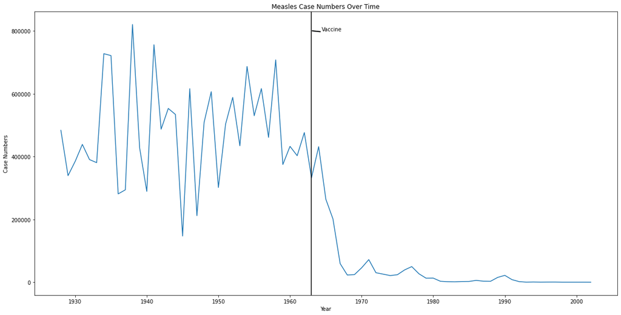

```python
measles_country, measles_population, measles_incidence = initial_dataframes(measles)
measles_incidence.plot.line(x = 'year', y = 'number', figsize=(20,10), legend=False, xlabel='Year', ylabel='Case Numbers') #Plotting case numbers

#Now to plot when the vaccine came out:
plt.axvline(x=vaccine_df[vaccine_df['Disease'] == 'Measles']['Year'].tolist()[0], color = 'black'); #Plotting a vertical line
plt.annotate(s = 'Vaccine', xy=(vaccine_df['Year'].loc[vaccine_df['Disease'] == 'Measles'], 800000), xytext=(20, 0.0055), textcoords='offset points', annotation_clip=True, arrowprops={'width': 1, 'headwidth': 1, 'headlength': 1, 'shrink':0.05});

plt.title("Measles Case Numbers Over Time"); #Giving graph a title
```

#### Polio

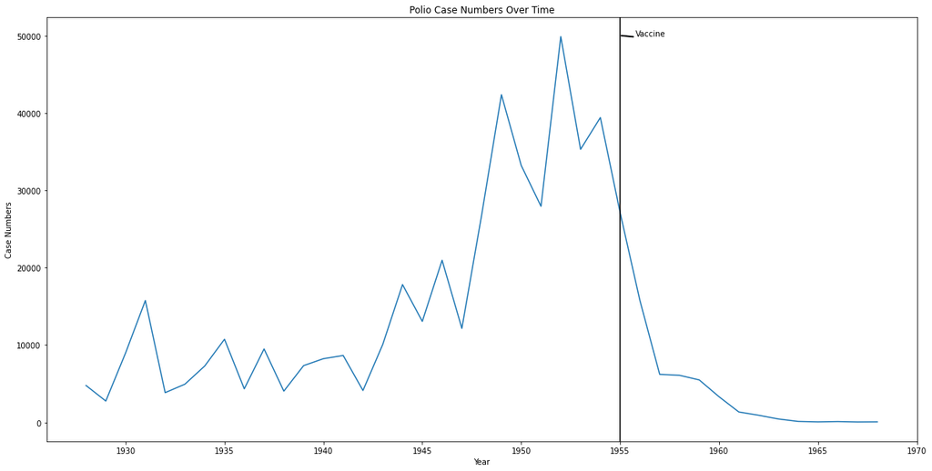

```python
polio_country, polio_population, polio_incidence = initial_dataframes(polio)
polio_incidence.plot.line(x = 'year', y = 'number', figsize=(20,10), legend=False, xlabel='Year', ylabel='Case Numbers') #Plotting case numbers

#Now to plot when the vaccine came out:
plt.axvline(x=vaccine_df[vaccine_df['Disease'] == 'Polio']['Year'].tolist()[0], color = 'black'); #Plotting a vertical line
plt.annotate(s = 'Vaccine', xy=(vaccine_df['Year'].loc[vaccine_df['Disease'] == 'Polio'], 50000), xytext=(20, 0.0055), textcoords='offset points', annotation_clip=True, arrowprops={'width': 1, 'headwidth': 1, 'headlength': 1, 'shrink':0.05});

plt.title("Polio Case Numbers Over Time"); #Giving graph a title
```

#### Smallpox

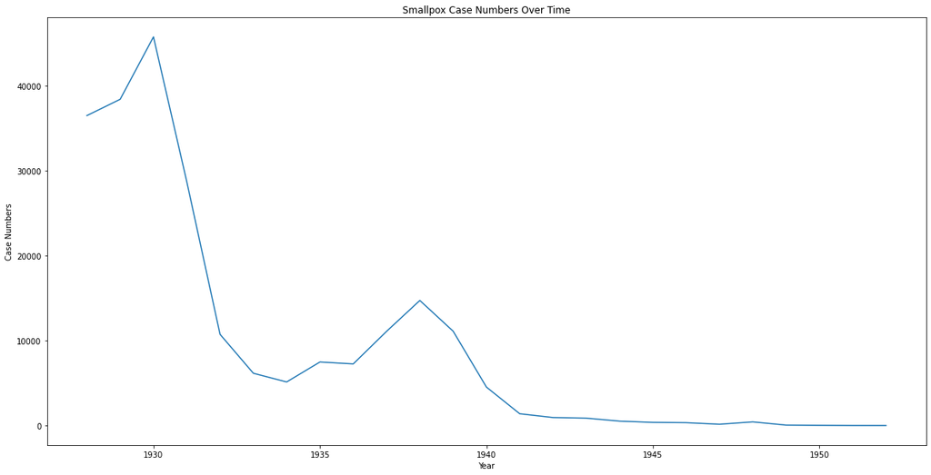

```python
smallpox_country, smallpox_population, smallpox_incidence = initial_dataframes(smallpox)
smallpox_incidence.plot.line(x = 'year', y = 'number', figsize=(20,10), legend=False, xlabel='Year', ylabel='Case Numbers')
plt.title("Smallpox Case Numbers Over Time"); #Giving graph a title
```

#### Pertussis

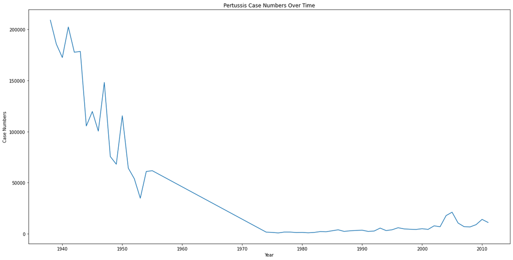

```python
pertussis_country, pertussis_population, pertussis_incidence = initial_dataframes(pertussis)
pertussis_incidence.plot.line(x = 'year', y = 'number', figsize=(20,10), legend=False, xlabel='Year', ylabel='Case Numbers')
plt.title("Pertussis Case Numbers Over Time"); #Giving graph a title
```

#### Hepatitis A

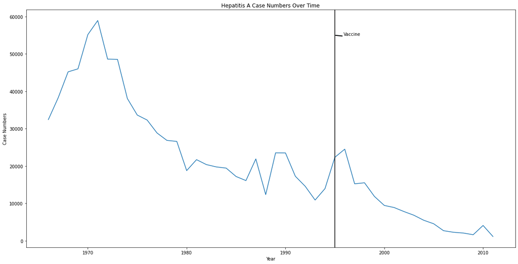

```python
hepa_country, hepa_population, hepa_incidence = initial_dataframes(hepa)
hepa_incidence.plot.line(x = 'year', y = 'number', figsize=(20,10),legend=False, xlabel='Year', ylabel='Case Numbers') #Plotting case numbers

#Now to plot when the vaccine came out:
plt.axvline(x=vaccine_df[vaccine_df['Disease'] == 'Hepatitis A']['Year'].tolist()[0], color = 'black'); #Plotting a vertical line
plt.annotate(s = 'Vaccine', xy=(vaccine_df['Year'].loc[vaccine_df['Disease'] == 'Hepatitis A'], 55000), xytext=(20, 0.0055), textcoords='offset points', annotation_clip=True, arrowprops={'width': 1, 'headwidth': 1, 'headlength': 1, 'shrink':0.05});

plt.title("Hepatitis A Case Numbers Over Time"); #Giving graph a title
```

#### Rubella

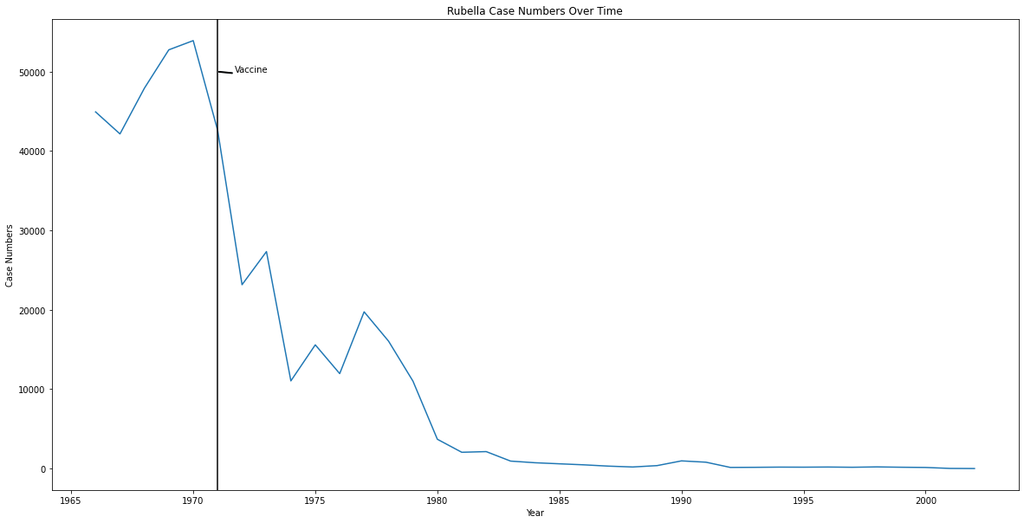

```python
rubella_country, rubella_population, rubella_incidence = initial_dataframes(rubella)
rubella_incidence.plot.line(x = 'year', y = 'number', figsize=(20,10), legend=False, xlabel='Year', ylabel='Case Numbers') #Plotting case numbers

#Now to plot when the vaccine came out:
plt.axvline(x=vaccine_df[vaccine_df['Disease'] == 'Rubella']['Year'].tolist()[0], color = 'black'); #Plotting a vertical line
plt.annotate(s = 'Vaccine', xy=(vaccine_df['Year'].loc[vaccine_df['Disease'] == 'Rubella'], 50000), xytext=(20, 0.0055), textcoords='offset points', annotation_clip=True, arrowprops={'width': 1, 'headwidth': 1, 'headlength': 1, 'shrink':0.05});

plt.title("Rubella Case Numbers Over Time"); #Giving graph a title
```

#### Mumps

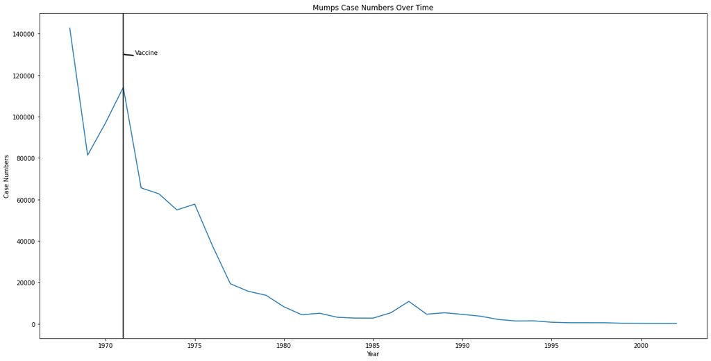

```python
mumps_country, mumps_population, mumps_incidence = initial_dataframes(mumps)
mumps_incidence.plot.line(x = 'year', y = 'number', figsize=(20,10), legend=False, xlabel='Year', ylabel='Case Numbers') #Plotting case numbers

#Now to plot when the vaccine came out:
plt.axvline(x=vaccine_df[vaccine_df['Disease'] == 'Mumps']['Year'].tolist()[0], color = 'black'); #Plotting a vertical line
plt.annotate(s = 'Vaccine', xy=(vaccine_df['Year'].loc[vaccine_df['Disease'] == 'Mumps'], 130000), xytext=(20, 0.0055), textcoords='offset points', annotation_clip=True, arrowprops={'width': 1, 'headwidth': 1, 'headlength': 1, 'shrink':0.05});

plt.title("Mumps Case Numbers Over Time"); #Giving graph a title
```

#### National Case Numbers and National Incidence

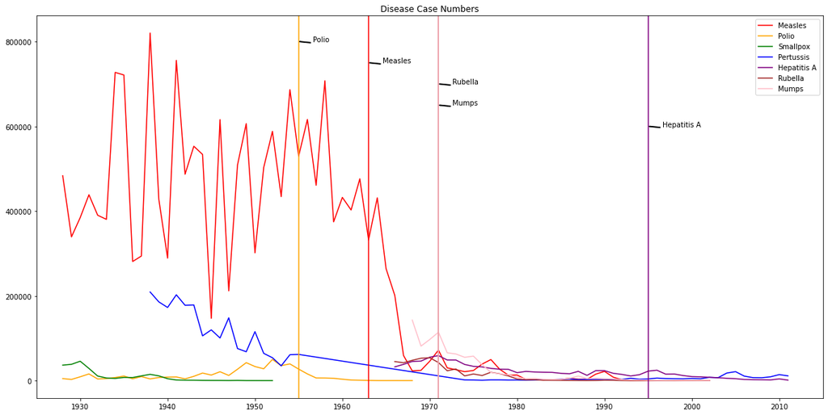

```python
fig = plt.figure(figsize=(20,10));

colors = ['red', 'orange', 'green', 'blue', 'purple', 'brown', 'pink']; #colors for legend
colors_2 = ['green', 'blue', 'orange', 'red', 'brown', 'pink', 'purple']; #colors matching vaccine dataset
i = 0

# Plotting each disease over time
for frame in [measles_incidence, polio_incidence, smallpox_incidence, pertussis_incidence, hepa_incidence, rubella_incidence, mumps_incidence]:
    plt.plot(frame['year'], frame['number'], color=f'{colors[i]}');
    i += 1

for i in range(0, len(vaccine_df)): #this plots vertical lines where the vaccines came out
  if vaccine_df.iloc[i].Year < 1930: #this removes the whitespace that appears before the graph because of the vaccines that came out before 1930
    continue
  plt.axvline(x=vaccine_df.iloc[i].Year, color = f'{colors_2[i]}'); #this matches the color of the vertical line to the color of the disease in the legend
  plt.annotate(s = f'{vaccine_df.iloc[i].Disease}', xy=(vaccine_df.iloc[i].Year, 900000 - i*50000), xytext=(20, 0.0055), textcoords='offset points', annotation_clip=True, arrowprops={'width': 1, 'headwidth': 1, 'headlength': 1, 'shrink':0.05});

plt.legend(["Measles", "Polio", "Smallpox", "Pertussis", "Hepatitis A", "Rubella", "Mumps"]);
plt.title("Disease Case Numbers");
plt.xlim(1925, 2015); #we have to cut off the limits because 2 of the vaccines appeared way before 1930 and make the graph hard to read
```

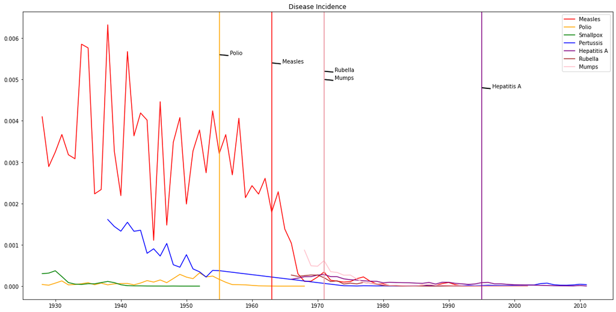

```python
fig = plt.figure(figsize=(20,10));

colors = ['red', 'orange', 'green', 'blue', 'purple', 'brown', 'pink']; #colors for legend
colors_2 = ['green', 'blue', 'orange', 'red', 'brown', 'pink', 'purple']; #colors matching vaccine dataset
i = 0

# Plotting each disease over time
for frame in [measles_incidence, polio_incidence, smallpox_incidence, pertussis_incidence, hepa_incidence, rubella_incidence, mumps_incidence]:
    plt.plot(frame['year'], frame['incidence'], color=f'{colors[i]}');
    i += 1

for i in range(0, len(vaccine_df)): #this plots vertical lines where the vaccines came out
  if vaccine_df.iloc[i].Year < 1930: #this removes the whitespace that appears before the graph because of the vaccines that came out before 1930
    continue
  plt.axvline(x=vaccine_df.iloc[i].Year, color = f'{colors_2[i]}'); #this matches the color of the vertical line to the color of the disease in the legend
  plt.annotate(s = f'{vaccine_df.iloc[i].Disease}', xy=(vaccine_df.iloc[i].Year, 0.006 - i*0.0002), xytext=(20, 0.0055), textcoords='offset points', annotation_clip=True, arrowprops={'width': 1, 'headwidth': 1, 'headlength': 1, 'shrink':0.05});

plt.legend(["Measles", "Polio", "Smallpox", "Pertussis", "Hepatitis A", "Rubella", "Mumps"]);
plt.title("Disease Incidence");
plt.xlim(1925, 2015); #we have to cut off the limits because 2 of the vaccines appeared way before 1930 and make the graph hard to read
```

It is worth nothing that the vaccines for Pertussis and Smallpox were released prior to the first collection year of this dataset, so they are nto marked

All of the vaccines seem to have been released after the peak of the disease which may speak to the either the speed and efficiency of US Public Health, the perceived need, or the state of science at the time.

## Exploratory Analysis & Data Visualization Part 1 - State to State Incidence

Now that we have a solid idea of what the trends look like on a national scale, we can zoom back in to look at individual states to try and see how they compare.

One great way to visualize disease incidence per state is to make a spatial heatmap of the US. Given any year and disease, we can use the Geopandas library to visualize the prevalence of the disease in each state.

#### Preparing a Dataset for Graphing

Cartographic Boundary Files 2012 - Shapefile of the United States: https://www.sciencebase.gov/catalog/item/52c78623e4b060b9ebca5be5

We originally got our data from the US Census, but there was too much data (each state had multiple coordinates for its regions). We found this dataset from sciencebase.gov, which is a U.S. Geological Survey Trusted Digital Repository. Their files are simpler and contain single coordinates for each state. We want only one row of data for each state so that we can easily join our data with our other datasets.

We followed these tutorials to implement our code:

https://mohammadimranhasan.com/geospatial-data-mapping-with-python/

https://towardsdatascience.com/lets-make-a-map-using-geopandas-pandas-and-matplotlib-to-make-a-chloropleth-map-dddc31c1983d

First, we need to install geopandas in order to create maps and import our coordinates file.

```python
!pip install geopandas
#!pip install --upgrade pyshp
#!pip install --upgrade shapely
#!pip install --upgrade descartes
```

We need to read in the zip file.

```python
import geopandas
states = geopandas.read_file("tl_2012_us_state.zip")

states.head()
```

|  | OBJECTID | REGION | DIVISION | STATEFP | STATENS | GEOID | STUSPS | NAME | LSAD | MTFCC | FUNCSTAT | ALAND | AWATER | INTPTLAT | INTPTLON | Shape_Leng | Shape_Area | geometry |
| --- | --- | --- | --- | --- | --- | --- | --- | --- | --- | --- | --- | --- | --- | --- | --- | --- | --- | --- |
| 0 | 1 | 4 | 9 | 15 | 01779782 | 15 | HI | Hawaii | 00 | G4000 | A | 1.663425e+10 | 1.167874e+10 | +19.8097670 | -155.5061027 | 2.419034e+06 | 3.268482e+10 | MULTIPOLYGON (((-17361760.204 2164544.588, -17... |
| 1 | 2 | 3 | 7 | 05 | 00068085 | 05 | AR | Arkansas | 00 | G4000 | A | 1.347726e+11 | 2.959210e+09 | +34.8955256 | -092.4446262 | 2.656648e+06 | 2.053261e+11 | POLYGON ((-10515267.713 4101325.818, -10515269... |
| 2 | 3 | 4 | 8 | 35 | 00897535 | 35 | NM | New Mexico | 00 | G4000 | A | 3.141611e+11 | 7.564385e+08 | +34.4346843 | -106.1316181 | 2.900368e+06 | 4.643927e+11 | POLYGON ((-12138963.727 4106855.170, -12138964... |
| 3 | 4 | 4 | 8 | 30 | 00767982 | 30 | MT | Montana | 00 | G4000 | A | 3.769636e+11 | 3.868565e+09 | +47.0511771 | -109.6348174 | 4.607246e+06 | 8.201836e+11 | POLYGON ((-12727480.235 5886876.586, -12727567... |
| 4 | 5 | 1 | 2 | 36 | 01779796 | 36 | NY | New York | 00 | G4000 | A | 1.220579e+11 | 1.923885e+10 | +42.9133974 | -075.5962723 | 3.212630e+06 | 2.637702e+11 | MULTIPOLYGON (((-8866092.533 5160809.769, -886... |

**Cleaning up the dataset**

There are some columns we don't need, and we can rename the columns to make them look neater.

```python
states.columns.unique() #grabbing column names
```

```
Index(['OBJECTID', 'REGION', 'DIVISION', 'STATEFP', 'STATENS', 'GEOID',
       'STUSPS', 'NAME', 'LSAD', 'MTFCC', 'FUNCSTAT', 'ALAND', 'AWATER',
       'INTPTLAT', 'INTPTLON', 'Shape_Leng', 'Shape_Area', 'geometry'],
      dtype='object')
```

```python
states.drop(columns=['OBJECTID', 'REGION', 'DIVISION', 'STATEFP', 'STATENS', 'GEOID',
       'STUSPS', 'LSAD', 'MTFCC', 'FUNCSTAT', 'ALAND', 'AWATER',
       'INTPTLAT', 'INTPTLON', 'Shape_Leng', 'Shape_Area'], inplace=True) #dropping unnecessary columns
states.rename(columns={'NAME':'State', 'geometry': 'Geometry'}, inplace=True) #renaming the columns to make them look prettier
states['State'] = states['State'].str.upper() #in order to join with previous datasets we want this to match
states.head()
```

|  | State | Geometry |
| --- | --- | --- |
| 0 | HAWAII | MULTIPOLYGON (((-17361760.204 2164544.588, -17... |
| 1 | ARKANSAS | POLYGON ((-10515267.713 4101325.818, -10515269... |
| 2 | NEW MEXICO | POLYGON ((-12138963.727 4106855.170, -12138964... |
| 3 | MONTANA | POLYGON ((-12727480.235 5886876.586, -12727567... |
| 4 | NEW YORK | MULTIPOLYGON (((-8866092.533 5160809.769, -886... |

```python
states.shape[0]
```

```
56
```

From the code above, we see that there are 56 rows, even though we know there are 50 states. By looking at the data, we see acquired regions of the US included, such as Puerto Rico and Guam. We need to keep this in mind for joining our data.

We need to check for NaN values.

```python
states.isnull().sum()
```

```
State       0
Geometry    0
dtype: int64
```

Perfect! We have no NaN values.

Just to test that we are using GeoPandas correctly, here is a simple map of the US.

```
(0.0, 12000000.0)
```

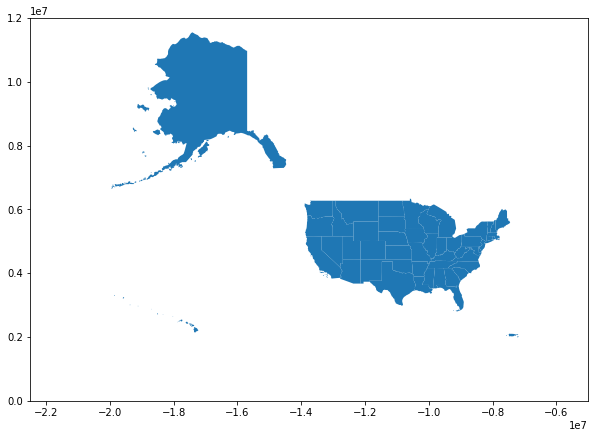

```python
states = geopandas.GeoDataFrame(states, geometry='Geometry') #turning the dataframe into a geodataframe object
states.plot(figsize=(10, 10))
plt.xlim(-2.25e7, -0.5e7)
plt.ylim(0.0, 1.2e7)
```

Great! We are good to move on with analysis. This work will be reffered to later in the seperate sections for national incidence of each disease

### Incidence Column Function

This function takes in one of the generic disease dfs and adds on a column called incidence that calculates the fraction of new cases/total populateion for every state. It returns 2 things - a DataFrame called states_disease_incidence that has the incidence for every states every year for the given disease, and a dictionary called states_disease which has seperate Dataframes for each state with the year and case number for the given disease

```python
#Incidence Column Function
def incidence_df(df):
  #create a dictionary of dataframs for every state
  states_disease = dict()
  for k, v in df.groupby('loc'):
    states_disease[k] = v

  #create an incidence column for every dataframe in the dictionary
  for i in states_disease:
    states_disease[i]['incidence'] = states_disease[i]['number']/states_disease[i]['population']
    #set the index to year for easy combining later
    states_disease[i].set_index('year', inplace = True)

  #create new dataframe of all of the incidences by state for every year
  states_disease_incidence = pd.DataFrame()

  #enter the incidence columns from the state datasets into the incidence dataset
  for i in states_disease:
    states_disease_incidence[i] = states_disease[i]['incidence']

  return states_disease_incidence, states_disease
```

### Map DF function

This function takes in the states disease DataFrame created in the incidence df function and properly formats it for ease of graphing with Geopandas.

```python
#create a DataFrame to make the visual map of incidence
def map_df(states_disease_incidence):
  map_disease_df = states_disease_incidence.T #transpose to get states in a column
  map_disease_df.reset_index(inplace=True)
  map_disease_df.rename(columns={'index':'State'}, inplace=True)
  map_disease_df = pd.merge(map_disease_df, states, on="State", how='left') #we want to use the keys of the incidence values because we know those are 50 states, not including Guam, etc.
  return map_disease_df
```

### Create Map Function

The create_map function takes in 'sel', the selected year we want to examine in the form of an integer, 'map_disease_df', the DataFrame we created in the map_df function specifically for graphing, and the name of the disease in the form of a string to properly label the resulting grpah.

The colormapped scalebar on the right changes per disease, but does not change depending on the year chosen because it is based on the min and max values per disease.

```python
def create_map(sel, map_disease_df, disease):
  map_disease_df = geopandas.GeoDataFrame(map_disease_df, geometry='Geometry') #turning the dataframe into a geodataframe object to be used with geopandas to plot

  #Here we are trying to find the min and max values to use for our scalebar
  #We don't want to do this for each year because looking at the graph over time would be misleading if you kept changing the scalebars
  map_disease_df.columns.unique()
  merged_cols = map_disease_df.columns.unique()

  merged_cols = merged_cols[1:-1] #only grabbing the years
  vmin = map_disease_df[merged_cols].min().min()
  vmax = map_disease_df[merged_cols].max().max()

  #Plotting
  fig, ax = plt.subplots(1, figsize=(10,7))
  map_disease_df.plot(column=sel, figsize=(10, 7), cmap='Blues', linewidth=0.8, ax=ax, edgecolor='0.8')
  plt.xlim(-2.25e7, -0.5e7) #resetting axes
  plt.ylim(0.5, 1.2e7)
  ax.axis('off') #remove axis because it means nothing for us

  ax.set_title(f'Incidence Rate of {disease} in {sel} across the US')

  sm = plt.cm.ScalarMappable(cmap='Blues', norm=plt.Normalize(vmin=vmin, vmax=vmax)) #for color scalebar
  sm._A = []
  cbar = fig.colorbar(sm)
```

### Creating and Graphing Incidence

We will now use the 3 functions created above to visualize the state incidences for any given year

#### Measles

```python
#utilize the above functions to create dictionary of state specific DataFrames
states_measles_incidence, states_measles = incidence_df(measles)
```

```python
states_measles_incidence.head()
```

| year | ALABAMA | ALASKA | ARIZONA | ARKANSAS | CALIFORNIA | COLORADO | CONNECTICUT | DELAWARE | DISTRICT OF COLUMBIA | FLORIDA | ... | SOUTH DAKOTA | TENNESSEE | TEXAS | UTAH | VERMONT | VIRGINIA | WASHINGTON | WEST VIRGINIA | WISCONSIN | WYOMING |
| --- | --- | --- | --- | --- | --- | --- | --- | --- | --- | --- | --- | --- | --- | --- | --- | --- | --- | --- | --- | --- | --- |
| 1928 | 0.003350 | NaN | 0.002007 | 0.004818 | 0.000692 | 0.002070 | 0.006350 | 0.002562 | 0.005357 | 0.001196 | ... | 0.001601 | 0.003154 | 0.000973 | 0.000169 | 0.003349 | NaN | 0.003448 | 0.001959 | 0.001246 | 0.002273 |
| 1929 | 0.001119 | NaN | 0.000549 | 0.000672 | 0.000728 | 0.000742 | 0.006148 | 0.002398 | 0.000942 | 0.000780 | ... | 0.001678 | 0.000330 | 0.000713 | 0.000689 | 0.001053 | NaN | 0.002486 | 0.003801 | 0.010165 | 0.003121 |
| 1930 | 0.001570 | NaN | 0.004664 | 0.000535 | 0.007602 | 0.011328 | 0.001122 | 0.001092 | 0.001822 | 0.003566 | ... | 0.003463 | 0.001799 | 0.000732 | 0.010448 | 0.002367 | NaN | 0.006316 | 0.001577 | 0.007485 | 0.003416 |
| 1931 | 0.003373 | NaN | 0.004977 | 0.000459 | 0.004775 | 0.004533 | 0.007905 | 0.010033 | 0.008329 | 0.002608 | ... | 0.002124 | 0.001348 | 0.000395 | 0.000298 | 0.003184 | NaN | 0.001974 | 0.002914 | 0.005066 | 0.000607 |
| 1932 | 0.000102 | NaN | 0.000202 | 0.000054 | 0.002141 | 0.002229 | 0.003483 | 0.000159 | 0.000532 | 0.000136 | ... | 0.000964 | 0.000690 | 0.000766 | 0.000139 | 0.011461 | 0.000534 | 0.006319 | 0.005997 | 0.009353 | 0.002422 |

5 rows × 51 columns

```python
states_measles['ALABAMA']
```

| year | disease | increase | loc | number | population | incidence |
| --- | --- | --- | --- | --- | --- | --- |
| 1928 | MEASLES | 334.99 | ALABAMA | 8843 | 2640000 | 3.349621e-03 |
| 1929 | MEASLES | 111.93 | ALABAMA | 2959 | 2644000 | 1.119138e-03 |
| 1930 | MEASLES | 157.00 | ALABAMA | 4156 | 2647000 | 1.570079e-03 |
| 1931 | MEASLES | 337.29 | ALABAMA | 8934 | 2649000 | 3.372593e-03 |
| 1932 | MEASLES | 10.21 | ALABAMA | 270 | 2653000 | 1.017716e-04 |
| ... | ... | ... | ... | ... | ... | ... |
| 1991 | MEASLES | 0.02 | ALABAMA | 1 | 4099156 | 2.439527e-07 |
| 1993 | MEASLES | 0.02 | ALABAMA | 1 | 4214202 | 2.372928e-07 |
| 1997 | MEASLES | 0.14 | ALABAMA | 6 | 4367935 | 1.373647e-06 |
| 1998 | MEASLES | 0.00 | ALABAMA | 0 | 4404701 | 0.000000e+00 |
| 2002 | MEASLES | 0.16 | ALABAMA | 7 | 4472420 | 1.565148e-06 |

66 rows × 6 columns

```python
map_measles_df = map_df(states_measles_incidence)
map_measles_df.head()
```

|  | State | 1928 | 1929 | 1930 | 1931 | 1932 | 1933 | 1934 | 1935 | 1936 | ... | 1987 | 1988 | 1989 | 1990 | 1991 | 1993 | 1997 | 1998 | 2002 | Geometry |
| --- | --- | --- | --- | --- | --- | --- | --- | --- | --- | --- | --- | --- | --- | --- | --- | --- | --- | --- | --- | --- | --- |
| 0 | ALABAMA | 0.003350 | 0.001119 | 0.001570 | 0.003373 | 0.000102 | 0.000652 | 0.005903 | 0.002653 | 0.000208 | ... | 9.940743e-07 | 2.481253e-07 | 0.000015 | 0.000007 | 2.439527e-07 | 2.372928e-07 | 0.000001 | 0.000000e+00 | 0.000002 | POLYGON ((-9841333.855 3579579.495, -9841349.6... |
| 1 | ALASKA | NaN | NaN | NaN | NaN | NaN | NaN | NaN | NaN | NaN | ... | NaN | 1.827622e-06 | 0.000000 | 0.000049 | 1.753792e-06 | NaN | 0.000002 | 2.580928e-05 | NaN | MULTIPOLYGON (((-15108567.654 8339788.089, -15... |
| 2 | ARIZONA | 0.002007 | 0.000549 | 0.004664 | 0.004977 | 0.000202 | 0.002960 | 0.002388 | 0.001350 | 0.005255 | ... | 9.900478e-06 | 8.282294e-07 | 0.000040 | 0.000077 | 9.027138e-05 | 7.379275e-07 | 0.000002 | 2.047778e-06 | NaN | POLYGON ((-12761162.105 4147165.875, -12761214... |
| 3 | ARKANSAS | 0.004818 | 0.000672 | 0.000535 | 0.000459 | 0.000054 | 0.002933 | 0.003846 | 0.000803 | 0.000057 | ... | NaN | NaN | 0.000002 | 0.000017 | NaN | NaN | 0.000001 | NaN | NaN | POLYGON ((-10515267.713 4101325.818, -10515269... |
| 4 | CALIFORNIA | 0.000692 | 0.000728 | 0.007602 | 0.004775 | 0.002141 | 0.004453 | 0.004233 | 0.004664 | 0.007735 | ... | 2.719200e-05 | 2.515558e-05 | 0.000074 | 0.000320 | 6.442247e-05 | 2.014393e-06 | 0.000001 | 1.212574e-07 | 0.000000 | MULTIPOLYGON (((-13060108.516 3854208.959, -13... |

5 rows × 68 columns

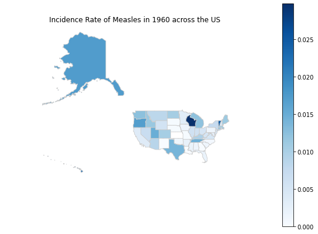

```python
create_map(1960, map_measles_df, 'Measles')
```

#### Polio

```python
#utilize the above functions to create dictionary of state specific DataFrames
states_polio_incidence, states_polio = incidence_df(polio)
```

```python
states_polio_incidence.head()
```

| year | ALABAMA | ALASKA | ARIZONA | ARKANSAS | CALIFORNIA | COLORADO | CONNECTICUT | DELAWARE | DISTRICT OF COLUMBIA | FLORIDA | ... | SOUTH DAKOTA | TENNESSEE | TEXAS | UTAH | VERMONT | VIRGINIA | WASHINGTON | WEST VIRGINIA | WISCONSIN | WYOMING |
| --- | --- | --- | --- | --- | --- | --- | --- | --- | --- | --- | --- | --- | --- | --- | --- | --- | --- | --- | --- | --- | --- |
| 1928 | 0.000023 | NaN | 0.000026 | 0.000005 | 0.000051 | 0.000070 | 0.000046 | 0.000034 | 0.000069 | 0.000015 | ... | 0.000064 | 0.000013 | 0.000007 | 0.000018 | 0.000073 | 0.000006 | 0.000208 | 0.000114 | 0.000017 | 0.000027 |
| 1929 | 0.000022 | NaN | 0.000021 | 0.000002 | 0.000028 | 0.000013 | 0.000013 | 0.000021 | 0.000012 | 0.000024 | ... | 0.000004 | 0.000036 | 0.000003 | 0.000008 | 0.000053 | 0.000099 | 0.000017 | 0.000034 | 0.000007 | 0.000013 |
| 1930 | 0.000025 | NaN | 0.000074 | 0.000042 | 0.000307 | 0.000063 | 0.000046 | 0.000025 | 0.000018 | 0.000008 | ... | 0.000202 | 0.000023 | 0.000022 | 0.000006 | 0.000008 | 0.000005 | 0.000030 | 0.000024 | 0.000061 | 0.000243 |
| 1931 | 0.000020 | NaN | 0.000026 | 0.000009 | 0.000043 | 0.000009 | 0.000700 | 0.000021 | 0.000030 | 0.000011 | ... | 0.000042 | 0.000018 | 0.000006 | 0.000010 | 0.000248 | 0.000010 | 0.000054 | 0.000047 | 0.000246 | 0.000026 |
| 1932 | 0.000013 | NaN | 0.000016 | 0.000008 | 0.000029 | 0.000008 | 0.000020 | 0.000045 | 0.000066 | 0.000005 | ... | 0.000022 | 0.000020 | 0.000012 | 0.000006 | 0.000006 | 0.000022 | 0.000047 | 0.000025 | 0.000019 | 0.000026 |

5 rows × 51 columns

```python
states_polio['ALABAMA']
```

| year | disease | increase | loc | number | population | incidence |
| --- | --- | --- | --- | --- | --- | --- |
| 1928 | POLIO | 2.39 | ALABAMA | 62 | 2640000 | 2.348485e-05 |
| 1929 | POLIO | 2.25 | ALABAMA | 58 | 2644000 | 2.193646e-05 |
| 1930 | POLIO | 2.57 | ALABAMA | 67 | 2647000 | 2.531167e-05 |
| 1931 | POLIO | 2.07 | ALABAMA | 54 | 2649000 | 2.038505e-05 |
| 1932 | POLIO | 1.38 | ALABAMA | 35 | 2653000 | 1.319261e-05 |
| 1933 | POLIO | 1.12 | ALABAMA | 28 | 2661000 | 1.052236e-05 |
| 1934 | POLIO | 1.89 | ALABAMA | 50 | 2685000 | 1.862197e-05 |
| 1935 | POLIO | 2.27 | ALABAMA | 61 | 2719000 | 2.243472e-05 |
| 1936 | POLIO | 15.36 | ALABAMA | 420 | 2743000 | 1.531170e-04 |
| 1937 | POLIO | 3.07 | ALABAMA | 84 | 2762000 | 3.041274e-05 |
| 1938 | POLIO | 3.36 | ALABAMA | 96 | 2787000 | 3.444564e-05 |
| 1939 | POLIO | 1.98 | ALABAMA | 56 | 2814000 | 1.990050e-05 |
| 1940 | POLIO | 1.62 | ALABAMA | 51 | 2845000 | 1.792619e-05 |
| 1941 | POLIO | 27.43 | ALABAMA | 796 | 2902000 | 2.742936e-04 |
| 1942 | POLIO | 4.61 | ALABAMA | 139 | 2941000 | 4.726284e-05 |
| 1943 | POLIO | 1.27 | ALABAMA | 40 | 2902000 | 1.378360e-05 |
| 1944 | POLIO | 3.39 | ALABAMA | 98 | 2802000 | 3.497502e-05 |
| 1945 | POLIO | 5.00 | ALABAMA | 140 | 2775000 | 5.045045e-05 |
| 1946 | POLIO | 10.85 | ALABAMA | 318 | 2911000 | 1.092408e-04 |
| 1947 | POLIO | 2.18 | ALABAMA | 68 | 2942000 | 2.311353e-05 |
| 1948 | POLIO | 6.83 | ALABAMA | 208 | 2969000 | 7.005726e-05 |
| 1949 | POLIO | 8.55 | ALABAMA | 256 | 3000000 | 8.533333e-05 |
| 1950 | POLIO | 9.13 | ALABAMA | 279 | 3058000 | 9.123610e-05 |
| 1951 | POLIO | 22.15 | ALABAMA | 677 | 3059000 | 2.213142e-04 |
| 1952 | POLIO | 13.56 | ALABAMA | 419 | 3068000 | 1.365711e-04 |
| 1953 | POLIO | 14.93 | ALABAMA | 457 | 3053000 | 1.496888e-04 |
| 1954 | POLIO | 12.47 | ALABAMA | 376 | 3014000 | 1.247512e-04 |
| 1955 | POLIO | 5.52 | ALABAMA | 169 | 3050000 | 5.540984e-05 |
| 1956 | POLIO | 3.46 | ALABAMA | 105 | 3071000 | 3.419082e-05 |
| 1957 | POLIO | 1.85 | ALABAMA | 59 | 3109000 | 1.897716e-05 |
| 1958 | POLIO | 1.92 | ALABAMA | 62 | 3163000 | 1.960164e-05 |
| 1959 | POLIO | 4.79 | ALABAMA | 154 | 3204000 | 4.806492e-05 |
| 1960 | POLIO | 0.69 | ALABAMA | 23 | 3274000 | 7.025046e-06 |
| 1961 | POLIO | 0.33 | ALABAMA | 11 | 3316000 | 3.317250e-06 |
| 1962 | POLIO | 0.66 | ALABAMA | 22 | 3323000 | 6.620524e-06 |
| 1963 | POLIO | 1.59 | ALABAMA | 53 | 3358000 | 1.578320e-05 |
| 1964 | POLIO | 0.06 | ALABAMA | 2 | 3395000 | 5.891016e-07 |
| 1966 | POLIO | 0.00 | ALABAMA | 0 | 3464000 | 0.000000e+00 |
| 1968 | POLIO | 0.03 | ALABAMA | 1 | 3446000 | 2.901915e-07 |

```python
map_polio_df = map_df(states_polio_incidence)
map_polio_df.head()
```

|  | State | 1928 | 1929 | 1930 | 1931 | 1932 | 1933 | 1934 | 1935 | 1936 | ... | 1958 | 1959 | 1960 | 1961 | 1962 | 1963 | 1964 | 1966 | 1968 | Geometry |
| --- | --- | --- | --- | --- | --- | --- | --- | --- | --- | --- | --- | --- | --- | --- | --- | --- | --- | --- | --- | --- | --- |
| 0 | ALABAMA | 0.000023 | 0.000022 | 0.000025 | 0.000020 | 0.000013 | 0.000011 | 0.000019 | 0.000022 | 0.000153 | ... | 0.000020 | 0.000048 | 0.000007 | 0.000003 | 0.000007 | 0.000016 | 5.891016e-07 | 0.000000e+00 | 2.901915e-07 | POLYGON ((-9841333.855 3579579.495, -9841349.6... |
| 1 | ALASKA | NaN | NaN | NaN | NaN | NaN | NaN | NaN | NaN | NaN | ... | 0.000009 | 0.000089 | 0.000009 | NaN | NaN | NaN | NaN | NaN | NaN | MULTIPOLYGON (((-15108567.654 8339788.089, -15... |
| 2 | ARIZONA | 0.000026 | 0.000021 | 0.000074 | 0.000026 | 0.000016 | 0.000038 | 0.000257 | 0.000048 | 0.000020 | ... | 0.000028 | 0.000049 | 0.000007 | 0.000006 | 0.000004 | 0.000002 | NaN | NaN | 5.945303e-07 | POLYGON ((-12761162.105 4147165.875, -12761214... |
| 3 | ARKANSAS | 0.000005 | 0.000002 | 0.000042 | 0.000009 | 0.000008 | 0.000007 | 0.000007 | 0.000015 | 0.000030 | ... | 0.000024 | 0.000110 | 0.000023 | 0.000014 | 0.000014 | 0.000003 | NaN | 5.265929e-07 | 5.257624e-07 | POLYGON ((-10515267.713 4101325.818, -10515269... |
| 4 | CALIFORNIA | 0.000051 | 0.000028 | 0.000307 | 0.000043 | 0.000029 | 0.000025 | 0.000540 | 0.000126 | 0.000059 | ... | 0.000021 | 0.000022 | 0.000026 | 0.000006 | 0.000005 | 0.000001 | 1.101868e-07 | 1.590837e-07 | 5.671857e-07 | MULTIPOLYGON (((-13060108.516 3854208.959, -13... |

5 rows × 41 columns

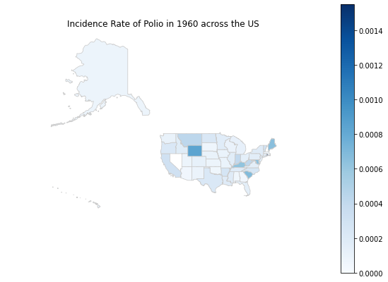

```python
create_map(1960, map_polio_df, 'Polio')
```

#### Pertussis

```python
#utilize the above functions to create dictionary of state specific DataFrames
states_pertussis_incidence, states_pertussis = incidence_df(pertussis)
```

```python
states_pertussis_incidence.head()
```

| year | ALABAMA | ALASKA | ARIZONA | ARKANSAS | CALIFORNIA | COLORADO | CONNECTICUT | DELAWARE | DISTRICT OF COLUMBIA | FLORIDA | ... | SOUTH DAKOTA | TENNESSEE | TEXAS | UTAH | VERMONT | VIRGINIA | WASHINGTON | WEST VIRGINIA | WISCONSIN | WYOMING |
| --- | --- | --- | --- | --- | --- | --- | --- | --- | --- | --- | --- | --- | --- | --- | --- | --- | --- | --- | --- | --- | --- |
| 1938 | 0.000661 | NaN | 0.003489 | 0.000804 | 0.002271 | 0.001477 | 0.002166 | 0.002292 | 0.000925 | 0.000458 | ... | 0.001160 | 0.000736 | 0.001573 | 0.004725 | 0.006935 | 0.001475 | 0.002615 | 0.001649 | 0.004112 | 0.002272 |
| 1939 | 0.000702 | NaN | 0.002138 | 0.000483 | 0.001245 | 0.001817 | 0.002378 | 0.002897 | 0.002271 | 0.000607 | ... | 0.000419 | 0.000785 | 0.000870 | 0.005843 | 0.008475 | 0.001275 | 0.000945 | 0.000809 | 0.003520 | 0.001907 |
| 1940 | 0.000434 | NaN | 0.001788 | 0.000415 | 0.001823 | 0.001107 | 0.001799 | 0.002264 | 0.001094 | 0.000349 | ... | 0.000284 | 0.000722 | 0.001278 | 0.007196 | 0.003793 | 0.001134 | 0.001164 | 0.000966 | 0.002249 | 0.000828 |
| 1941 | 0.000540 | NaN | 0.002400 | 0.000568 | 0.002622 | 0.004182 | 0.001591 | 0.001004 | 0.000937 | 0.000371 | ... | 0.000954 | 0.000865 | 0.001620 | 0.005018 | 0.001828 | 0.001467 | 0.002582 | 0.001201 | 0.002861 | 0.001534 |
| 1942 | 0.000558 | NaN | 0.002048 | 0.000464 | 0.001556 | 0.001626 | 0.002181 | 0.000545 | 0.001090 | 0.000381 | ... | 0.000411 | 0.000656 | 0.001155 | 0.002614 | 0.006061 | 0.000847 | 0.001579 | 0.000765 | 0.003420 | 0.001382 |

5 rows × 51 columns

```python
states_pertussis['ALABAMA']
```

| year | disease | increase | loc | number | population | incidence |
| --- | --- | --- | --- | --- | --- | --- |
| 1938 | PERTUSSIS | 66.01 | ALABAMA | 1843 | 2787000 | 6.612845e-04 |
| 1939 | PERTUSSIS | 69.98 | ALABAMA | 1975 | 2814000 | 7.018479e-04 |
| 1940 | PERTUSSIS | 43.18 | ALABAMA | 1235 | 2845000 | 4.340949e-04 |
| 1941 | PERTUSSIS | 53.93 | ALABAMA | 1566 | 2902000 | 5.396278e-04 |
| 1942 | PERTUSSIS | 55.64 | ALABAMA | 1640 | 2941000 | 5.576335e-04 |
| 1943 | PERTUSSIS | 70.66 | ALABAMA | 2054 | 2902000 | 7.077877e-04 |
| 1944 | PERTUSSIS | 46.83 | ALABAMA | 1314 | 2802000 | 4.689507e-04 |
| 1945 | PERTUSSIS | 38.78 | ALABAMA | 1081 | 2775000 | 3.895495e-04 |
| 1946 | PERTUSSIS | 35.99 | ALABAMA | 1048 | 2911000 | 3.600137e-04 |
| 1947 | PERTUSSIS | 76.40 | ALABAMA | 2249 | 2942000 | 7.644460e-04 |
| 1948 | PERTUSSIS | 42.48 | ALABAMA | 1263 | 2969000 | 4.253958e-04 |
| 1949 | PERTUSSIS | 17.20 | ALABAMA | 515 | 3000000 | 1.716667e-04 |
| 1950 | PERTUSSIS | 38.47 | ALABAMA | 1177 | 3058000 | 3.848921e-04 |
| 1951 | PERTUSSIS | 39.51 | ALABAMA | 1209 | 3059000 | 3.952272e-04 |
| 1952 | PERTUSSIS | 30.46 | ALABAMA | 945 | 3068000 | 3.080183e-04 |
| 1953 | PERTUSSIS | 10.38 | ALABAMA | 317 | 3053000 | 1.038323e-04 |
| 1954 | PERTUSSIS | 24.79 | ALABAMA | 748 | 3014000 | 2.481752e-04 |
| 1955 | PERTUSSIS | 58.12 | ALABAMA | 1774 | 3050000 | 5.816393e-04 |
| 1974 | PERTUSSIS | 0.52 | ALABAMA | 19 | 3678814 | 5.164708e-06 |
| 1975 | PERTUSSIS | 1.24 | ALABAMA | 46 | 3735139 | 1.231547e-05 |
| 1976 | PERTUSSIS | 0.17 | ALABAMA | 6 | 3780403 | 1.587132e-06 |
| 1977 | PERTUSSIS | 0.11 | ALABAMA | 4 | 3831836 | 1.043886e-06 |
| 1978 | PERTUSSIS | 0.08 | ALABAMA | 3 | 3866248 | 7.759461e-07 |
| 1979 | PERTUSSIS | 0.12 | ALABAMA | 4 | 3893888 | 1.027251e-06 |
| 1980 | PERTUSSIS | 0.11 | ALABAMA | 4 | 3918531 | 1.020791e-06 |
| 1982 | PERTUSSIS | 0.14 | ALABAMA | 5 | 3934102 | 1.270938e-06 |
| 1983 | PERTUSSIS | 0.11 | ALABAMA | 4 | 3951820 | 1.012192e-06 |
| 1984 | PERTUSSIS | 0.03 | ALABAMA | 1 | 3972523 | 2.517292e-07 |
| 1985 | PERTUSSIS | 0.77 | ALABAMA | 29 | 3991569 | 7.265313e-06 |
| 1986 | PERTUSSIS | 0.52 | ALABAMA | 24 | 4015264 | 5.977191e-06 |
| 1987 | PERTUSSIS | 0.59 | ALABAMA | 26 | 4023844 | 6.461483e-06 |
| 1988 | PERTUSSIS | 1.48 | ALABAMA | 62 | 4030222 | 1.538377e-05 |
| 1989 | PERTUSSIS | 2.32 | ALABAMA | 97 | 4040587 | 2.400641e-05 |
| 1990 | PERTUSSIS | 1.77 | ALABAMA | 76 | 4050055 | 1.876518e-05 |
| 1991 | PERTUSSIS | 1.53 | ALABAMA | 65 | 4099156 | 1.585692e-05 |
| 1992 | PERTUSSIS | 0.51 | ALABAMA | 24 | 4154014 | 5.777544e-06 |
| 1993 | PERTUSSIS | 1.54 | ALABAMA | 67 | 4214202 | 1.589862e-05 |
| 1994 | PERTUSSIS | 0.88 | ALABAMA | 39 | 4260229 | 9.154437e-06 |
| 1995 | PERTUSSIS | 0.88 | ALABAMA | 38 | 4296800 | 8.843791e-06 |
| 1996 | PERTUSSIS | 0.61 | ALABAMA | 28 | 4331102 | 6.464867e-06 |
| 1997 | PERTUSSIS | 0.81 | ALABAMA | 37 | 4367935 | 8.470822e-06 |
| 1998 | PERTUSSIS | 0.55 | ALABAMA | 24 | 4404701 | 5.448724e-06 |
| 1999 | PERTUSSIS | 0.45 | ALABAMA | 20 | 4430141 | 4.514529e-06 |
| 2000 | PERTUSSIS | 0.35 | ALABAMA | 17 | 4451849 | 3.818638e-06 |
| 2001 | PERTUSSIS | 0.73 | ALABAMA | 35 | 4464034 | 7.840442e-06 |
| 2002 | PERTUSSIS | 0.78 | ALABAMA | 37 | 4472420 | 8.272926e-06 |
| 2003 | PERTUSSIS | 0.28 | ALABAMA | 14 | 4490591 | 3.117630e-06 |
| 2004 | PERTUSSIS | 0.89 | ALABAMA | 41 | 4512190 | 9.086497e-06 |
| 2005 | PERTUSSIS | 1.76 | ALABAMA | 82 | 4545049 | 1.804161e-05 |
| 2006 | PERTUSSIS | 1.94 | ALABAMA | 90 | 4597688 | 1.957506e-05 |
| 2007 | PERTUSSIS | 1.54 | ALABAMA | 72 | 4637904 | 1.552425e-05 |
| 2008 | PERTUSSIS | 1.05 | ALABAMA | 50 | 4677464 | 1.068955e-05 |
| 2009 | PERTUSSIS | 3.49 | ALABAMA | 167 | 4708708 | 3.546620e-05 |
| 2010 | PERTUSSIS | 2.34 | ALABAMA | 113 | 4729656 | 2.389180e-05 |
| 2011 | PERTUSSIS | 2.16 | ALABAMA | 106 | 4802740 | 2.207073e-05 |

```python
map_pertussis_df = map_df(states_pertussis_incidence)
map_pertussis_df.head()
```

|  | State | 1938 | 1939 | 1940 | 1941 | 1942 | 1943 | 1944 | 1945 | 1946 | ... | 2003 | 2004 | 2005 | 2006 | 2007 | 2008 | 2009 | 2010 | 2011 | Geometry |
| --- | --- | --- | --- | --- | --- | --- | --- | --- | --- | --- | --- | --- | --- | --- | --- | --- | --- | --- | --- | --- | --- |
| 0 | ALABAMA | 0.000661 | 0.000702 | 0.000434 | 0.000540 | 0.000558 | 0.000708 | 0.000469 | 0.000390 | 0.000360 | ... | 0.000003 | 0.000009 | 0.000018 | 0.000020 | 0.000016 | 0.000011 | 0.000035 | 0.000024 | 0.000022 | POLYGON ((-9841333.855 3579579.495, -9841349.6... |
| 1 | ALASKA | NaN | NaN | NaN | NaN | NaN | NaN | NaN | NaN | NaN | ... | 0.000009 | 0.000017 | 0.000184 | 0.000078 | 0.000054 | 0.000278 | 0.000100 | 0.000059 | 0.000037 | MULTIPOLYGON (((-15108567.654 8339788.089, -15... |
| 2 | ARIZONA | 0.003489 | 0.002138 | 0.001788 | 0.002400 | 0.002048 | 0.001366 | 0.001598 | 0.001436 | 0.001135 | ... | 0.000016 | 0.000036 | 0.000159 | 0.000057 | 0.000031 | 0.000016 | 0.000023 | 0.000027 | 0.000041 | POLYGON ((-12761162.105 4147165.875, -12761214... |
| 3 | ARKANSAS | 0.000804 | 0.000483 | 0.000415 | 0.000568 | 0.000464 | 0.000794 | 0.000552 | 0.000392 | 0.000271 | ... | 0.000011 | 0.000028 | 0.000104 | 0.000021 | 0.000030 | 0.000020 | 0.000036 | 0.000023 | 0.000017 | POLYGON ((-10515267.713 4101325.818, -10515269... |
| 4 | CALIFORNIA | 0.002271 | 0.001245 | 0.001823 | 0.002622 | 0.001556 | 0.001501 | 0.000620 | 0.001200 | 0.000424 | ... | 0.000018 | 0.000014 | 0.000045 | 0.000023 | 0.000003 | 0.000008 | 0.000011 | 0.000034 | 0.000030 | MULTIPOLYGON (((-13060108.516 3854208.959, -13... |

5 rows × 57 columns

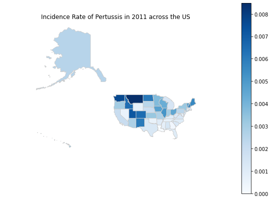

```python
create_map(2011, map_pertussis_df, 'Pertussis')
```

#### Smallpox

```python
#utilize the above functions to create dictionary of state specific DataFrames
states_smallpox_incidence, states_smallpox = incidence_df(smallpox)
```

```python
states_smallpox_incidence.head()
```

| year | ALABAMA | ARIZONA | ARKANSAS | CALIFORNIA | COLORADO | CONNECTICUT | DELAWARE | DISTRICT OF COLUMBIA | FLORIDA | GEORGIA | ... | SOUTH DAKOTA | TENNESSEE | TEXAS | UTAH | VERMONT | VIRGINIA | WASHINGTON | WEST VIRGINIA | WISCONSIN | WYOMING |
| --- | --- | --- | --- | --- | --- | --- | --- | --- | --- | --- | --- | --- | --- | --- | --- | --- | --- | --- | --- | --- | --- |
| 1928 | 0.000129 | 0.000972 | 0.000134 | 0.000185 | 0.000335 | 0.000102 | 0.000009 | 0.000021 | 0.000110 | 0.000005 | ... | 0.000511 | 0.000258 | 0.000316 | 0.000821 | 0.000028 | 8.213552e-07 | 0.001031 | 0.000767 | 0.000283 | 0.000732 |
| 1929 | 0.000143 | 0.000642 | 0.000107 | 0.000363 | 0.000837 | 0.000027 | 0.000008 | 0.000000 | 0.000025 | 0.000019 | ... | 0.001587 | 0.000094 | 0.000424 | 0.000327 | 0.000387 | 2.597938e-05 | 0.001329 | 0.000351 | 0.000232 | 0.001498 |
| 1930 | 0.000073 | 0.001263 | 0.000221 | 0.000402 | 0.000540 | 0.000000 | 0.000000 | 0.000000 | 0.000019 | 0.000000 | ... | 0.002007 | 0.000162 | 0.000468 | 0.000053 | 0.000219 | 4.120313e-06 | 0.001496 | 0.000451 | 0.000308 | 0.001111 |
| 1931 | 0.000111 | 0.000107 | 0.000407 | 0.000239 | 0.000251 | 0.000061 | 0.000000 | 0.000000 | 0.000019 | 0.000016 | ... | 0.000964 | 0.000133 | 0.000305 | 0.000033 | 0.000663 | 4.907975e-06 | 0.000657 | 0.000144 | 0.000124 | 0.000236 |
| 1932 | 0.000176 | 0.000016 | 0.000196 | 0.000084 | 0.000057 | 0.000053 | 0.000000 | 0.000002 | 0.000022 | 0.000005 | ... | 0.000228 | 0.000162 | 0.000179 | 0.000008 | 0.000486 | 4.078303e-06 | 0.000420 | 0.000035 | 0.000029 | 0.000100 |

5 rows × 49 columns

```python
states_smallpox['ALABAMA']
```

| year | disease | increase | loc | number | population | incidence |
| --- | --- | --- | --- | --- | --- | --- |
| 1928 | SMALLPOX | 12.96 | ALABAMA | 341 | 2640000 | 1.291667e-04 |
| 1929 | SMALLPOX | 14.33 | ALABAMA | 378 | 2644000 | 1.429652e-04 |
| 1930 | SMALLPOX | 7.28 | ALABAMA | 192 | 2647000 | 7.253495e-05 |
| 1931 | SMALLPOX | 11.18 | ALABAMA | 295 | 2649000 | 1.113628e-04 |
| 1932 | SMALLPOX | 17.64 | ALABAMA | 467 | 2653000 | 1.760271e-04 |
| 1933 | SMALLPOX | 3.14 | ALABAMA | 82 | 2661000 | 3.081548e-05 |
| 1934 | SMALLPOX | 0.87 | ALABAMA | 23 | 2685000 | 8.566108e-06 |
| 1935 | SMALLPOX | 1.55 | ALABAMA | 42 | 2719000 | 1.544686e-05 |
| 1936 | SMALLPOX | 0.45 | ALABAMA | 12 | 2743000 | 4.374772e-06 |
| 1937 | SMALLPOX | 1.97 | ALABAMA | 54 | 2762000 | 1.955105e-05 |
| 1938 | SMALLPOX | 2.55 | ALABAMA | 74 | 2787000 | 2.655185e-05 |
| 1939 | SMALLPOX | 1.74 | ALABAMA | 52 | 2814000 | 1.847903e-05 |
| 1940 | SMALLPOX | 1.65 | ALABAMA | 49 | 2845000 | 1.722320e-05 |
| 1941 | SMALLPOX | 0.34 | ALABAMA | 12 | 2902000 | 4.135079e-06 |
| 1942 | SMALLPOX | 0.41 | ALABAMA | 13 | 2941000 | 4.420265e-06 |
| 1943 | SMALLPOX | 0.61 | ALABAMA | 20 | 2902000 | 6.891799e-06 |
| 1944 | SMALLPOX | 0.42 | ALABAMA | 12 | 2802000 | 4.282655e-06 |
| 1945 | SMALLPOX | 0.20 | ALABAMA | 5 | 2775000 | 1.801802e-06 |
| 1946 | SMALLPOX | 0.16 | ALABAMA | 5 | 2911000 | 1.717623e-06 |
| 1947 | SMALLPOX | 0.18 | ALABAMA | 6 | 2942000 | 2.039429e-06 |
| 1948 | SMALLPOX | 0.45 | ALABAMA | 15 | 2969000 | 5.052206e-06 |
| 1951 | SMALLPOX | 0.03 | ALABAMA | 1 | 3059000 | 3.269042e-07 |

```python
map_smallpox_df = map_df(states_smallpox_incidence)
map_smallpox_df.head()
```

|  | State | 1928 | 1929 | 1930 | 1931 | 1932 | 1933 | 1934 | 1935 | 1936 | ... | 1941 | 1942 | 1943 | 1944 | 1945 | 1946 | 1947 | 1948 | 1951 | Geometry |
| --- | --- | --- | --- | --- | --- | --- | --- | --- | --- | --- | --- | --- | --- | --- | --- | --- | --- | --- | --- | --- | --- |
| 0 | ALABAMA | 0.000129 | 0.000143 | 0.000073 | 0.000111 | 0.000176 | 0.000031 | 0.000009 | 0.000015 | 0.000004 | ... | 0.000004 | 4.420265e-06 | 6.891799e-06 | 0.000004 | 1.801802e-06 | 0.000002 | 2.039429e-06 | 0.000005 | 3.269042e-07 | POLYGON ((-9841333.855 3579579.495, -9841349.6... |
| 1 | ARIZONA | 0.000972 | 0.000642 | 0.001263 | 0.000107 | 0.000016 | 0.000023 | 0.000007 | 0.000005 | 0.000007 | ... | 0.000033 | 9.541985e-06 | 8.670520e-06 | 0.000011 | 5.050505e-06 | 0.000003 | 0.000000e+00 | 0.000003 | 3.821656e-06 | POLYGON ((-12761162.105 4147165.875, -12761214... |
| 2 | ARKANSAS | 0.000134 | 0.000107 | 0.000221 | 0.000407 | 0.000196 | 0.000124 | 0.000057 | 0.000032 | 0.000007 | ... | 0.000017 | 3.136065e-05 | 3.092784e-05 | 0.000012 | 1.759364e-05 | 0.000006 | 2.178649e-06 | 0.000011 | NaN | POLYGON ((-10515267.713 4101325.818, -10515269... |
| 3 | CALIFORNIA | 0.000185 | 0.000363 | 0.000402 | 0.000239 | 0.000084 | 0.000178 | 0.000030 | 0.000048 | 0.000018 | ... | 0.000002 | 9.049774e-07 | 4.702563e-07 | 0.000002 | 5.351027e-07 | 0.000001 | 1.017087e-07 | 0.000004 | NaN | MULTIPOLYGON (((-13060108.516 3854208.959, -13... |
| 4 | COLORADO | 0.000335 | 0.000837 | 0.000540 | 0.000251 | 0.000057 | 0.000156 | 0.000143 | 0.000160 | 0.000180 | ... | 0.000045 | 1.886792e-05 | 1.040763e-05 | 0.000011 | 5.376344e-06 | 0.000011 | 8.084074e-07 | 0.000013 | NaN | POLYGON ((-12139399.612 4944791.641, -12139399... |

5 rows × 24 columns

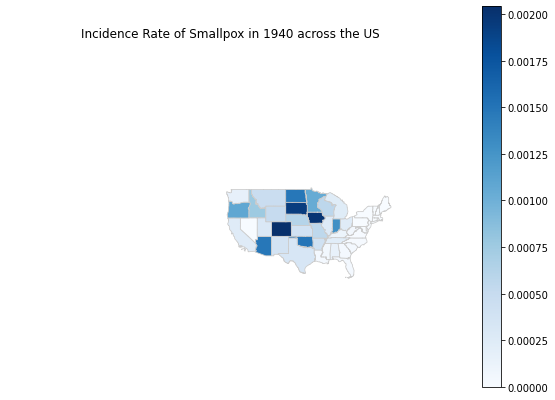

```python
create_map(1940, map_smallpox_df, 'Smallpox')
```

#### Hepatitis A

```python
#utilize the above functions to create dictionary of state specific DataFrames
states_hepa_incidence, states_hepa = incidence_df(hepa)
```

```python
states_hepa_incidence.head()
```

| year | ALABAMA | ALASKA | ARIZONA | ARKANSAS | CALIFORNIA | COLORADO | CONNECTICUT | DELAWARE | DISTRICT OF COLUMBIA | FLORIDA | ... | SOUTH DAKOTA | TENNESSEE | TEXAS | UTAH | VERMONT | VIRGINIA | WASHINGTON | WEST VIRGINIA | WISCONSIN | WYOMING |
| --- | --- | --- | --- | --- | --- | --- | --- | --- | --- | --- | --- | --- | --- | --- | --- | --- | --- | --- | --- | --- | --- |
| 1966 | 0.000093 | 0.000332 | 0.000257 | 0.000157 | 0.000315 | 0.000145 | 0.000115 | 0.000153 | 0.000048 | 0.000106 | ... | 0.000020 | 0.000261 | 0.000172 | 0.000168 | 0.000056 | 0.000130 | 0.000189 | 0.000137 | 0.000088 | 0.000167 |
| 1967 | 0.000084 | 0.000140 | 0.000237 | 0.000155 | 0.000390 | 0.000143 | 0.000199 | 0.000330 | 0.000053 | 0.000103 | ... | 0.000019 | 0.000217 | 0.000257 | 0.000155 | 0.000035 | 0.000157 | 0.000277 | 0.000205 | 0.000104 | 0.000202 |
| 1968 | 0.000091 | 0.000295 | 0.000253 | 0.000087 | 0.000558 | 0.000337 | 0.000169 | 0.000273 | 0.000086 | 0.000173 | ... | 0.000115 | 0.000267 | 0.000202 | 0.000252 | 0.000156 | 0.000127 | 0.000364 | 0.000189 | 0.000125 | 0.000114 |
| 1969 | 0.000110 | 0.000213 | 0.000304 | 0.000099 | 0.000459 | 0.000271 | 0.000206 | 0.000124 | 0.000076 | 0.000204 | ... | 0.000129 | 0.000260 | 0.000209 | 0.000271 | 0.000341 | 0.000093 | 0.000377 | 0.000194 | 0.000095 | 0.000246 |
| 1970 | 0.000118 | 0.000358 | 0.000324 | 0.000107 | 0.000463 | 0.000397 | 0.000281 | 0.000239 | 0.000116 | 0.000252 | ... | 0.000031 | 0.000316 | 0.000238 | 0.000282 | 0.000808 | 0.000285 | 0.000399 | 0.000216 | 0.000108 | 0.000244 |

5 rows × 51 columns

```python
states_hepa['ALABAMA']
```

| year | disease | increase | loc | number | population | incidence |
| --- | --- | --- | --- | --- | --- | --- |
| 1966 | HEPATITIS A | 9.28 | ALABAMA | 321 | 3464000 | 0.000093 |
| 1967 | HEPATITIS A | 8.42 | ALABAMA | 291 | 3458000 | 0.000084 |
| 1968 | HEPATITIS A | 9.18 | ALABAMA | 314 | 3446000 | 0.000091 |
| 1969 | HEPATITIS A | 11.02 | ALABAMA | 380 | 3440000 | 0.000110 |
| 1970 | HEPATITIS A | 11.80 | ALABAMA | 413 | 3497076 | 0.000118 |
| 1971 | HEPATITIS A | 10.66 | ALABAMA | 378 | 3539400 | 0.000107 |
| 1972 | HEPATITIS A | 9.57 | ALABAMA | 342 | 3579780 | 0.000096 |
| 1973 | HEPATITIS A | 12.93 | ALABAMA | 467 | 3626499 | 0.000129 |
| 1974 | HEPATITIS A | 6.58 | ALABAMA | 244 | 3678814 | 0.000066 |
| 1975 | HEPATITIS A | 7.65 | ALABAMA | 286 | 3735139 | 0.000077 |
| 1976 | HEPATITIS A | 5.86 | ALABAMA | 220 | 3780403 | 0.000058 |
| 1977 | HEPATITIS A | 5.38 | ALABAMA | 206 | 3831836 | 0.000054 |
| 1978 | HEPATITIS A | 5.29 | ALABAMA | 203 | 3866248 | 0.000053 |
| 1979 | HEPATITIS A | 6.64 | ALABAMA | 257 | 3893888 | 0.000066 |
| 1980 | HEPATITIS A | 5.09 | ALABAMA | 200 | 3918531 | 0.000051 |
| 1981 | HEPATITIS A | 3.59 | ALABAMA | 138 | 3925266 | 0.000035 |
| 1982 | HEPATITIS A | 3.33 | ALABAMA | 128 | 3934102 | 0.000033 |
| 1983 | HEPATITIS A | 4.56 | ALABAMA | 178 | 3951820 | 0.000045 |
| 1984 | HEPATITIS A | 2.97 | ALABAMA | 115 | 3972523 | 0.000029 |
| 1985 | HEPATITIS A | 1.01 | ALABAMA | 37 | 3991569 | 0.000009 |
| 1986 | HEPATITIS A | 1.18 | ALABAMA | 51 | 4015264 | 0.000013 |
| 1987 | HEPATITIS A | 1.91 | ALABAMA | 81 | 4023844 | 0.000020 |
| 1988 | HEPATITIS A | 0.30 | ALABAMA | 13 | 4030222 | 0.000003 |
| 1989 | HEPATITIS A | 1.29 | ALABAMA | 56 | 4040587 | 0.000014 |
| 1990 | HEPATITIS A | 2.05 | ALABAMA | 86 | 4050055 | 0.000021 |
| 1991 | HEPATITIS A | 0.87 | ALABAMA | 39 | 4099156 | 0.000010 |
| 1992 | HEPATITIS A | 0.81 | ALABAMA | 35 | 4154014 | 0.000008 |
| 1993 | HEPATITIS A | 0.94 | ALABAMA | 40 | 4214202 | 0.000009 |
| 1994 | HEPATITIS A | 1.68 | ALABAMA | 72 | 4260229 | 0.000017 |
| 1995 | HEPATITIS A | 1.77 | ALABAMA | 75 | 4296800 | 0.000017 |
| 1996 | HEPATITIS A | 4.55 | ALABAMA | 196 | 4331102 | 0.000045 |
| 1997 | HEPATITIS A | 0.90 | ALABAMA | 40 | 4367935 | 0.000009 |
| 1998 | HEPATITIS A | 1.47 | ALABAMA | 64 | 4404701 | 0.000015 |
| 1999 | HEPATITIS A | 1.17 | ALABAMA | 52 | 4430141 | 0.000012 |
| 2000 | HEPATITIS A | 1.15 | ALABAMA | 53 | 4451849 | 0.000012 |
| 2001 | HEPATITIS A | 1.41 | ALABAMA | 66 | 4464034 | 0.000015 |
| 2002 | HEPATITIS A | 0.75 | ALABAMA | 35 | 4472420 | 0.000008 |
| 2003 | HEPATITIS A | 0.28 | ALABAMA | 14 | 4490591 | 0.000003 |
| 2004 | HEPATITIS A | 0.12 | ALABAMA | 6 | 4512190 | 0.000001 |
| 2005 | HEPATITIS A | 0.71 | ALABAMA | 34 | 4545049 | 0.000007 |
| 2006 | HEPATITIS A | 0.35 | ALABAMA | 17 | 4597688 | 0.000004 |
| 2007 | HEPATITIS A | 0.41 | ALABAMA | 20 | 4637904 | 0.000004 |
| 2008 | HEPATITIS A | 0.20 | ALABAMA | 10 | 4677464 | 0.000002 |
| 2009 | HEPATITIS A | 0.20 | ALABAMA | 10 | 4708708 | 0.000002 |
| 2010 | HEPATITIS A | 0.16 | ALABAMA | 8 | 4729656 | 0.000002 |
| 2011 | HEPATITIS A | 0.14 | ALABAMA | 7 | 4802740 | 0.000001 |

```python
map_hepa_df = map_df(states_hepa_incidence)
map_hepa_df.head()
```

|  | State | 1966 | 1967 | 1968 | 1969 | 1970 | 1971 | 1972 | 1973 | 1974 | ... | 2003 | 2004 | 2005 | 2006 | 2007 | 2008 | 2009 | 2010 | 2011 | Geometry |
| --- | --- | --- | --- | --- | --- | --- | --- | --- | --- | --- | --- | --- | --- | --- | --- | --- | --- | --- | --- | --- | --- |
| 0 | ALABAMA | 0.000093 | 0.000084 | 0.000091 | 0.000110 | 0.000118 | 0.000107 | 0.000096 | 0.000129 | 0.000066 | ... | 0.000003 | 0.000001 | 0.000007 | 0.000004 | 0.000004 | 0.000002 | 0.000002 | 0.000002 | 0.000001 | POLYGON ((-9841333.855 3579579.495, -9841349.6... |
| 1 | ALASKA | 0.000332 | 0.000140 | 0.000295 | 0.000213 | 0.000358 | 0.000296 | 0.000602 | 0.000660 | 0.000659 | ... | 0.000012 | 0.000006 | 0.000004 | NaN | 0.000004 | 0.000004 | 0.000009 | 0.000006 | 0.000001 | MULTIPOLYGON (((-15108567.654 8339788.089, -15... |
| 2 | ARIZONA | 0.000257 | 0.000237 | 0.000253 | 0.000304 | 0.000324 | 0.000446 | 0.000311 | 0.000072 | 0.000224 | ... | 0.000042 | 0.000036 | 0.000040 | 0.000011 | 0.000026 | 0.000016 | 0.000011 | 0.000011 | 0.000003 | POLYGON ((-12761162.105 4147165.875, -12761214... |
| 3 | ARKANSAS | 0.000157 | 0.000155 | 0.000087 | 0.000099 | 0.000107 | 0.000117 | 0.000135 | 0.000067 | 0.000206 | ... | 0.000006 | 0.000019 | 0.000006 | 0.000008 | 0.000004 | 0.000001 | 0.000002 | 0.000000 | 0.000000 | POLYGON ((-10515267.713 4101325.818, -10515269... |
| 4 | CALIFORNIA | 0.000315 | 0.000390 | 0.000558 | 0.000459 | 0.000463 | 0.000467 | 0.000345 | 0.000325 | 0.000258 | ... | 0.000030 | 0.000022 | 0.000025 | 0.000019 | 0.000009 | 0.000009 | 0.000006 | 0.000005 | 0.000005 | MULTIPOLYGON (((-13060108.516 3854208.959, -13... |

5 rows × 48 columns

[figure not shown]

```python
create_map(2011, map_hepa_df, 'Pertussis')
```

#### Rubella

```python
#utilize the above functions to create dictionary of state specific DataFrames
states_rubella_incidence, states_rubella = incidence_df(rubella)
```

```python
states_rubella_incidence.head()
```

| year | ALABAMA | ALASKA | ARIZONA | ARKANSAS | CALIFORNIA | COLORADO | CONNECTICUT | DELAWARE | DISTRICT OF COLUMBIA | FLORIDA | ... | SOUTH DAKOTA | TENNESSEE | TEXAS | UTAH | VERMONT | VIRGINIA | WASHINGTON | WEST VIRGINIA | WISCONSIN | WYOMING |
| --- | --- | --- | --- | --- | --- | --- | --- | --- | --- | --- | --- | --- | --- | --- | --- | --- | --- | --- | --- | --- | --- |
| 1966 | 0.000032 | 0.000413 | 0.001595 | 0.000005 | 0.000149 | 0.000370 | 0.000756 | 0.000103 | 0.000019 | 0.000231 | ... | 0.000003 | 0.000676 | 0.000013 | 0.000080 | 0.000385 | 0.000216 | 0.001024 | 0.000573 | 0.001194 | 0.000740 |
| 1967 | 0.000062 | 0.001137 | 0.000593 | 0.000009 | 0.000473 | 0.000882 | 0.000622 | 0.000141 | 0.000009 | 0.000184 | ... | 0.000004 | 0.000333 | 0.000059 | 0.000080 | 0.000506 | 0.000144 | 0.000955 | 0.000334 | 0.000713 | 0.000012 |
| 1968 | 0.000117 | 0.001014 | 0.000416 | 0.000002 | 0.000252 | 0.000418 | 0.001025 | 0.000281 | 0.000018 | 0.000229 | ... | NaN | 0.000293 | 0.000265 | 0.000107 | 0.000212 | 0.000140 | 0.000561 | 0.000499 | 0.000686 | 0.000037 |
| 1969 | 0.000040 | 0.001574 | 0.000471 | 0.000104 | 0.000306 | 0.000635 | 0.000548 | 0.000365 | 0.000209 | 0.000299 | ... | NaN | 0.000428 | 0.000378 | 0.000146 | 0.000275 | 0.000334 | 0.000540 | 0.001348 | 0.000720 | 0.000246 |
| 1970 | 0.000109 | 0.000269 | 0.000328 | 0.000019 | 0.000258 | 0.000188 | 0.000203 | 0.000081 | 0.000028 | 0.000466 | ... | 0.000006 | 0.000381 | 0.000723 | 0.000157 | 0.000150 | 0.000162 | 0.001415 | 0.000800 | 0.000514 | 0.000400 |

5 rows × 51 columns

```python
states_rubella['ALABAMA']
```

| year | disease | increase | loc | number | population | incidence |
| --- | --- | --- | --- | --- | --- | --- |
| 1966 | RUBELLA | 3.25 | ALABAMA | 112 | 3464000 | 3.233256e-05 |
| 1967 | RUBELLA | 6.22 | ALABAMA | 214 | 3458000 | 6.188548e-05 |
| 1968 | RUBELLA | 11.75 | ALABAMA | 404 | 3446000 | 1.172374e-04 |
| 1969 | RUBELLA | 3.99 | ALABAMA | 136 | 3440000 | 3.953488e-05 |
| 1970 | RUBELLA | 10.84 | ALABAMA | 380 | 3497076 | 1.086622e-04 |
| 1971 | RUBELLA | 6.41 | ALABAMA | 226 | 3539400 | 6.385263e-05 |
| 1972 | RUBELLA | 1.95 | ALABAMA | 68 | 3579780 | 1.899558e-05 |
| 1973 | RUBELLA | 6.14 | ALABAMA | 220 | 3626499 | 6.066457e-05 |
| 1974 | RUBELLA | 1.78 | ALABAMA | 65 | 3678814 | 1.766874e-05 |
| 1975 | RUBELLA | 0.64 | ALABAMA | 23 | 3735139 | 6.157736e-06 |
| 1976 | RUBELLA | 0.06 | ALABAMA | 2 | 3780403 | 5.290441e-07 |
| 1977 | RUBELLA | 2.85 | ALABAMA | 109 | 3831836 | 2.844589e-05 |
| 1978 | RUBELLA | 0.82 | ALABAMA | 31 | 3866248 | 8.018110e-06 |
| 1979 | RUBELLA | 1.17 | ALABAMA | 44 | 3893888 | 1.129976e-05 |
| 1980 | RUBELLA | 0.12 | ALABAMA | 4 | 3918531 | 1.020791e-06 |
| 1981 | RUBELLA | 0.03 | ALABAMA | 1 | 3925266 | 2.547598e-07 |
| 1983 | RUBELLA | 0.03 | ALABAMA | 1 | 3951820 | 2.530480e-07 |
| 1984 | RUBELLA | 0.08 | ALABAMA | 3 | 3972523 | 7.551876e-07 |
| 1989 | RUBELLA | 0.02 | ALABAMA | 1 | 4040587 | 2.474888e-07 |
| 1990 | RUBELLA | 0.02 | ALABAMA | 1 | 4050055 | 2.469102e-07 |
| 1996 | RUBELLA | 0.05 | ALABAMA | 2 | 4331102 | 4.617762e-07 |
| 1998 | RUBELLA | 0.00 | ALABAMA | 0 | 4404701 | 0.000000e+00 |
| 1999 | RUBELLA | 0.02 | ALABAMA | 1 | 4430141 | 2.257264e-07 |
| 2000 | RUBELLA | 0.07 | ALABAMA | 3 | 4451849 | 6.738773e-07 |

```python
map_rubella_df = map_df(states_rubella_incidence)
map_rubella_df.head()
```

|  | State | 1966 | 1967 | 1968 | 1969 | 1970 | 1971 | 1972 | 1973 | 1974 | ... | 1981 | 1983 | 1984 | 1989 | 1990 | 1996 | 1998 | 1999 | 2000 | Geometry |
| --- | --- | --- | --- | --- | --- | --- | --- | --- | --- | --- | --- | --- | --- | --- | --- | --- | --- | --- | --- | --- | --- |
| 0 | ALABAMA | 0.000032 | 0.000062 | 0.000117 | 0.000040 | 0.000109 | 0.000064 | 0.000019 | 0.000061 | 1.766874e-05 | ... | 2.547598e-07 | 2.530480e-07 | 7.551876e-07 | 2.474888e-07 | 2.469102e-07 | 4.617762e-07 | 0.000000e+00 | 2.257264e-07 | 6.738773e-07 | POLYGON ((-9841333.855 3579579.495, -9841349.6... |
| 1 | ALASKA | 0.000413 | 0.001137 | 0.001014 | 0.001574 | 0.000269 | 0.000126 | 0.000085 | 0.000085 | NaN | ... | 2.224170e-06 | 1.946654e-06 | 1.877952e-06 | NaN | NaN | NaN | NaN | NaN | NaN | MULTIPOLYGON (((-15108567.654 8339788.089, -15... |
| 2 | ARIZONA | 0.001595 | 0.000593 | 0.000416 | 0.000471 | 0.000328 | 0.000200 | 0.000173 | 0.000012 | 8.753321e-07 | ... | 7.612823e-06 | 2.608297e-06 | 1.256464e-06 | NaN | 8.414545e-06 | 2.180103e-07 | 4.095556e-07 | 2.189568e-06 | 1.935473e-07 | POLYGON ((-12761162.105 4147165.875, -12761214... |
| 3 | ARKANSAS | 0.000005 | 0.000009 | 0.000002 | 0.000104 | 0.000019 | 0.000167 | 0.000035 | 0.000049 | 3.704517e-06 | ... | 3.051097e-06 | NaN | 1.289188e-06 | 4.254007e-07 | 1.273028e-06 | NaN | NaN | 7.541876e-07 | NaN | POLYGON ((-10515267.713 4101325.818, -10515269... |
| 4 | CALIFORNIA | 0.000149 | 0.000473 | 0.000252 | 0.000306 | 0.000258 | 0.000407 | 0.000230 | 0.000119 | 6.639475e-05 | ... | 1.913779e-05 | 1.029237e-05 | 6.089003e-06 | 3.797040e-06 | 1.552095e-05 | 1.499118e-06 | 6.062870e-08 | 1.492573e-07 | 3.235811e-07 | MULTIPOLYGON (((-13060108.516 3854208.959, -13... |

5 rows × 26 columns

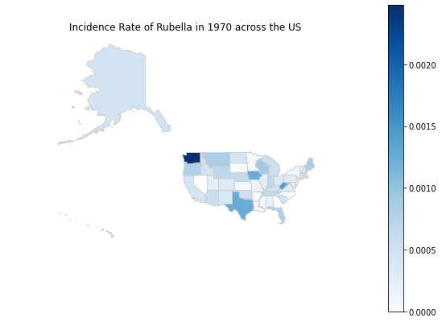

```python
create_map(1970, map_rubella_df, 'Rubella')
```

#### Mumps

```python
#utilize the above functions to create dictionary of state specific DataFrames
states_mumps_incidence, states_mumps = incidence_df(mumps)
```

```python
states_mumps_incidence.head()
```

| year | ALABAMA | ALASKA | ARIZONA | ARKANSAS | CALIFORNIA | COLORADO | CONNECTICUT | DELAWARE | DISTRICT OF COLUMBIA | FLORIDA | ... | SOUTH DAKOTA | TENNESSEE | TEXAS | UTAH | VERMONT | VIRGINIA | WASHINGTON | WEST VIRGINIA | WISCONSIN | WYOMING |
| --- | --- | --- | --- | --- | --- | --- | --- | --- | --- | --- | --- | --- | --- | --- | --- | --- | --- | --- | --- | --- | --- |
| 1968 | 0.000159 | 0.002519 | 0.001197 | 0.000010 | 0.000871 | 0.001325 | 0.001294 | 0.000566 | 0.000303 | 0.000347 | ... | NaN | 0.001532 | 0.001039 | 0.000675 | 0.002898 | 0.000278 | 0.002006 | 0.001976 | 0.003547 | 0.001231 |
| 1969 | 0.000068 | 0.003108 | 0.001210 | 0.000047 | 0.000407 | 0.000397 | 0.001328 | 0.000241 | 0.000121 | 0.000248 | ... | NaN | 0.000585 | 0.000731 | 0.000319 | 0.002872 | 0.000280 | 0.001302 | 0.001574 | 0.001948 | 0.000024 |
| 1970 | 0.000112 | 0.000919 | 0.000521 | 0.000079 | 0.000306 | 0.000666 | 0.001192 | 0.000648 | 0.000291 | 0.000406 | ... | 0.000086 | 0.000823 | 0.000519 | 0.000117 | 0.001620 | 0.000469 | 0.001691 | 0.001432 | 0.002543 | 0.000129 |
| 1971 | 0.000290 | 0.000287 | 0.000620 | 0.000078 | 0.000365 | 0.000656 | 0.000516 | 0.000321 | 0.000132 | 0.000384 | ... | 0.000444 | 0.001245 | 0.000750 | 0.000172 | 0.000764 | 0.000222 | 0.001847 | 0.001431 | 0.003726 | 0.001226 |
| 1972 | 0.000237 | 0.000771 | 0.000459 | 0.000105 | 0.000341 | 0.000331 | 0.000365 | 0.000306 | 0.000042 | 0.000180 | ... | 0.000177 | 0.000512 | 0.000410 | 0.000121 | 0.000292 | 0.000268 | 0.001139 | 0.001411 | 0.001797 | 0.000983 |

5 rows × 51 columns

```python
states_mumps['ALABAMA']
```

| year | disease | increase | loc | number | population | incidence |
| --- | --- | --- | --- | --- | --- | --- |
| 1968 | MUMPS | 15.94 | ALABAMA | 548 | 3446000 | 1.590250e-04 |
| 1969 | MUMPS | 6.85 | ALABAMA | 234 | 3440000 | 6.802326e-05 |
| 1970 | MUMPS | 11.20 | ALABAMA | 392 | 3497076 | 1.120936e-04 |
| 1971 | MUMPS | 28.97 | ALABAMA | 1025 | 3539400 | 2.895971e-04 |
| 1972 | MUMPS | 23.72 | ALABAMA | 849 | 3579780 | 2.371654e-04 |
| 1973 | MUMPS | 20.85 | ALABAMA | 755 | 3626499 | 2.081898e-04 |
| 1974 | MUMPS | 16.66 | ALABAMA | 613 | 3678814 | 1.666298e-04 |
| 1975 | MUMPS | 12.17 | ALABAMA | 453 | 3735139 | 1.212806e-04 |
| 1976 | MUMPS | 10.30 | ALABAMA | 389 | 3780403 | 1.028991e-04 |
| 1977 | MUMPS | 7.54 | ALABAMA | 288 | 3831836 | 7.515979e-05 |
| 1978 | MUMPS | 11.30 | ALABAMA | 437 | 3866248 | 1.130295e-04 |
| 1979 | MUMPS | 0.77 | ALABAMA | 28 | 3893888 | 7.190756e-06 |
| 1980 | MUMPS | 0.92 | ALABAMA | 34 | 3918531 | 8.676721e-06 |
| 1981 | MUMPS | 0.51 | ALABAMA | 19 | 3925266 | 4.840436e-06 |
| 1982 | MUMPS | 0.29 | ALABAMA | 10 | 3934102 | 2.541876e-06 |
| 1983 | MUMPS | 0.06 | ALABAMA | 2 | 3951820 | 5.060959e-07 |
| 1984 | MUMPS | 0.15 | ALABAMA | 5 | 3972523 | 1.258646e-06 |
| 1985 | MUMPS | 0.03 | ALABAMA | 1 | 3991569 | 2.505281e-07 |
| 1986 | MUMPS | 0.08 | ALABAMA | 4 | 4015264 | 9.961985e-07 |
| 1987 | MUMPS | 1.52 | ALABAMA | 64 | 4023844 | 1.590519e-05 |
| 1988 | MUMPS | 0.41 | ALABAMA | 18 | 4030222 | 4.466255e-06 |
| 1989 | MUMPS | 0.66 | ALABAMA | 30 | 4040587 | 7.424664e-06 |
| 1990 | MUMPS | 0.42 | ALABAMA | 19 | 4050055 | 4.691294e-06 |
| 1991 | MUMPS | 0.29 | ALABAMA | 14 | 4099156 | 3.415337e-06 |
| 1992 | MUMPS | 0.25 | ALABAMA | 12 | 4154014 | 2.888772e-06 |
| 1993 | MUMPS | 0.49 | ALABAMA | 22 | 4214202 | 5.220443e-06 |
| 1994 | MUMPS | 0.29 | ALABAMA | 12 | 4260229 | 2.816750e-06 |
| 1995 | MUMPS | 0.04 | ALABAMA | 2 | 4296800 | 4.654627e-07 |
| 1996 | MUMPS | 0.15 | ALABAMA | 7 | 4331102 | 1.616217e-06 |
| 1997 | MUMPS | 0.16 | ALABAMA | 8 | 4367935 | 1.831529e-06 |
| 1998 | MUMPS | 0.08 | ALABAMA | 4 | 4404701 | 9.081207e-07 |
| 1999 | MUMPS | 0.24 | ALABAMA | 11 | 4430141 | 2.482991e-06 |
| 2000 | MUMPS | 0.08 | ALABAMA | 4 | 4451849 | 8.985031e-07 |
| 2002 | MUMPS | 0.04 | ALABAMA | 2 | 4472420 | 4.471852e-07 |

```python
map_mumps_df = map_df(states_mumps_incidence)
map_mumps_df.head()
```

|  | State | 1968 | 1969 | 1970 | 1971 | 1972 | 1973 | 1974 | 1975 | 1976 | ... | 1993 | 1994 | 1995 | 1996 | 1997 | 1998 | 1999 | 2000 | 2002 | Geometry |
| --- | --- | --- | --- | --- | --- | --- | --- | --- | --- | --- | --- | --- | --- | --- | --- | --- | --- | --- | --- | --- | --- |
| 0 | ALABAMA | 0.000159 | 0.000068 | 0.000112 | 0.000290 | 0.000237 | 0.000208 | 0.000167 | 0.000121 | 0.000103 | ... | 0.000005 | 0.000003 | 4.654627e-07 | 1.616217e-06 | 0.000002 | 9.081207e-07 | 0.000002 | 8.985031e-07 | 4.471852e-07 | POLYGON ((-9841333.855 3579579.495, -9841349.6... |
| 1 | ALASKA | 0.002519 | 0.003108 | 0.000919 | 0.000287 | 0.000771 | 0.002557 | 0.000396 | 0.000130 | 0.000094 | ... | 0.000018 | 0.000007 | 1.985401e-05 | 4.929597e-06 | 0.000007 | 3.226160e-06 | 0.000005 | 1.274902e-05 | NaN | MULTIPOLYGON (((-15108567.654 8339788.089, -15... |
| 2 | ARIZONA | 0.001197 | 0.001210 | 0.000521 | 0.000620 | 0.000459 | 0.000074 | NaN | NaN | NaN | ... | 0.000005 | 0.000023 | 1.353638e-06 | 2.180103e-07 | 0.000007 | 1.228667e-06 | 0.000002 | 1.161284e-06 | 0.000000e+00 | POLYGON ((-12761162.105 4147165.875, -12761214... |
| 3 | ARKANSAS | 0.000010 | 0.000047 | 0.000079 | 0.000078 | 0.000105 | 0.000160 | 0.000085 | 0.000085 | 0.000037 | ... | 0.000002 | 0.000002 | 3.944152e-06 | 3.887860e-07 | 0.000000 | 3.426889e-06 | NaN | 1.866864e-06 | NaN | POLYGON ((-10515267.713 4101325.818, -10515269... |
| 4 | CALIFORNIA | 0.000871 | 0.000407 | 0.000306 | 0.000365 | 0.000341 | 0.000268 | 0.000116 | 0.000170 | 0.000079 | ... | 0.000005 | 0.000005 | 6.467574e-06 | 3.185625e-06 | 0.000004 | 1.940119e-06 | 0.000002 | 1.853237e-06 | 1.892408e-06 | MULTIPOLYGON (((-13060108.516 3854208.959, -13... |

5 rows × 36 columns

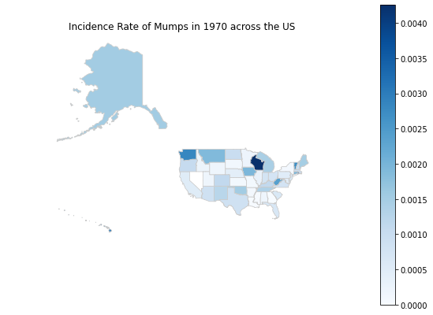

```python
create_map(1970, map_mumps_df, 'Mumps')
```

## Exploratory Analysis & Data Visualization Part 2 - Incidence Analysis

Now that we have an understanding and datasets portraying incidence on a national and state wide scale, we can see how the states compare to the national average and establish a ranking of what states were affected by a given disease the most each year.

We will start by creating a dataset that has the incidence for every state every year as well as the entire country.

```python
def US_state_df(disease_incidence, states_disease_incidence):
  #reset index to year for joining
  disease_incidence.set_index('year', inplace = True)

  #grab the national incidence and add it into a new dataframe with state incidences
  US = disease_incidence['incidence']
  US_state_disease_incidence = states_disease_incidence.join(US)

  #rename column
  US_state_disease_incidence.rename(columns={'incidence':'UNITED STATES'}, inplace = True)

  return US_state_disease_incidence
```

```python
def graph_state_incidence(US_state_disease_incidence):

  states = list(US_state_disease_incidence.columns)
  states.remove('UNITED STATES')

  disease_compare_incidence = US_state_disease_incidence[states].div(US_state_disease_incidence['UNITED STATES'], axis=0)

  disease_hist = pd.DataFrame()

  for state in disease_compare_incidence:
    count = disease_compare_incidence[state][disease_compare_incidence[state] > 1].count()
    disease_hist.insert(0, state, [count])

  disease_hist = disease_hist.T
  disease_hist.sort_values(0, ascending = False, inplace = True)

  disease_hist.plot.bar(title='Number Of Times State Incidence is Above National Average Incidence', figsize=(20, 10), legend=False)
```

### Measles

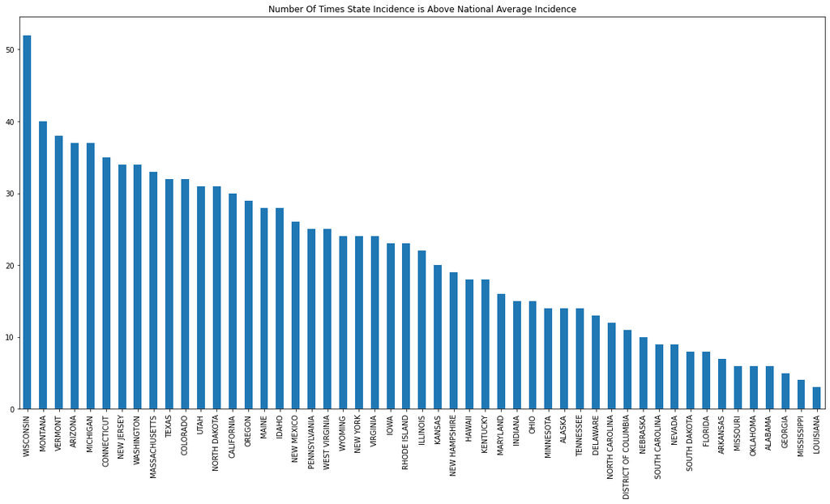

```python
US_state_measles_incidence = US_state_df(measles_incidence, states_measles_incidence)
graph_state_incidence(US_state_measles_incidence)
```

### Polio

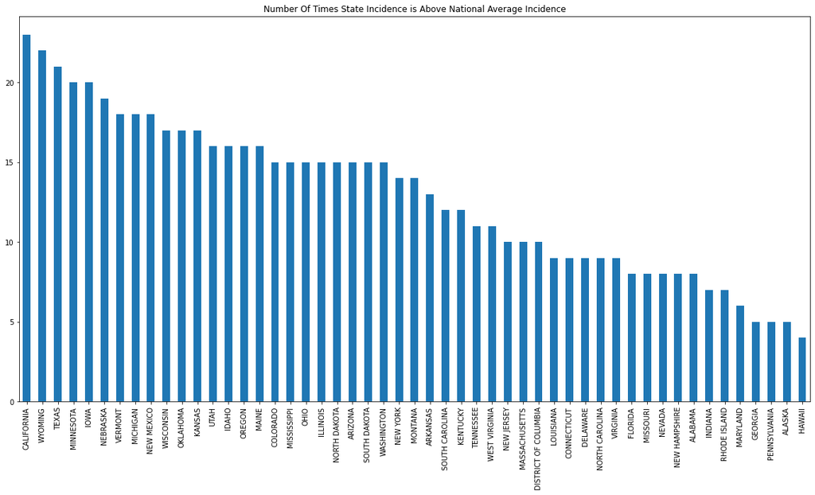

```python
US_state_polio_incidence = US_state_df(polio_incidence, states_polio_incidence)
graph_state_incidence(US_state_polio_incidence)
```

### Pertussis

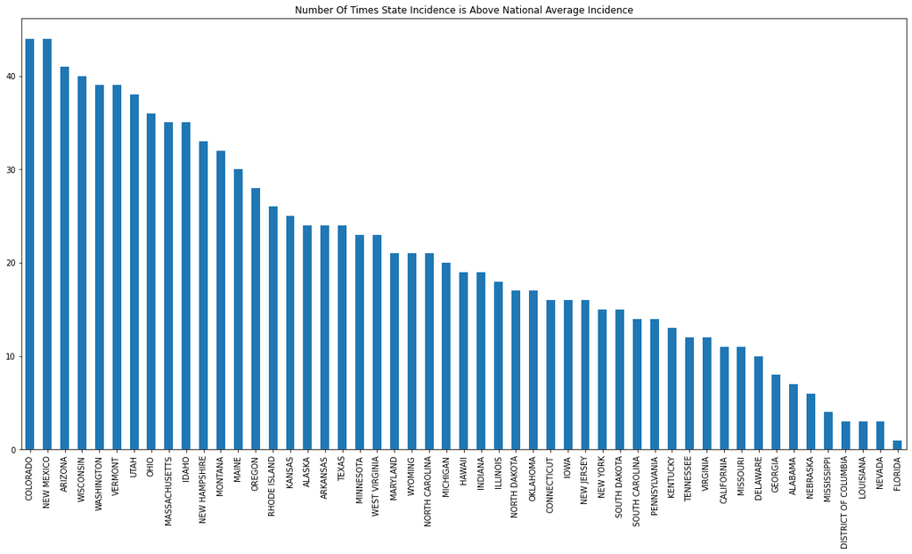

```python
US_state_pertussis_incidence = US_state_df(pertussis_incidence, states_pertussis_incidence)
graph_state_incidence(US_state_pertussis_incidence)
```

### Smallpox

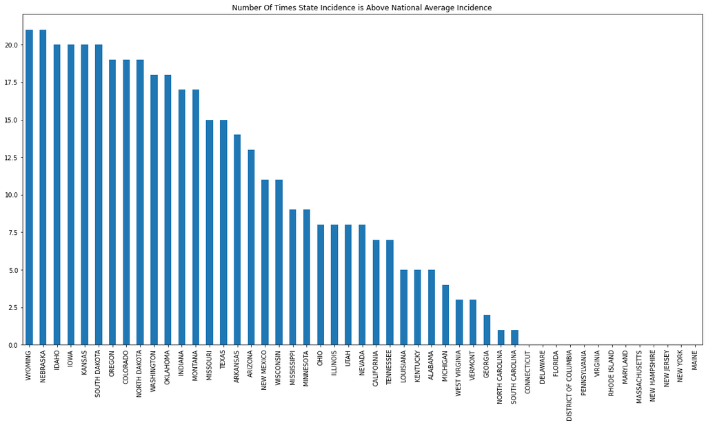

```python
US_state_smallpox_incidence = US_state_df(smallpox_incidence, states_smallpox_incidence)
graph_state_incidence(US_state_smallpox_incidence)
```

### Hepatitis A

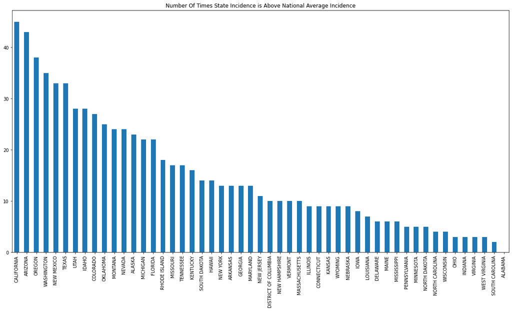

```python
US_state_hepa_incidence = US_state_df(hepa_incidence, states_hepa_incidence)
graph_state_incidence(US_state_hepa_incidence)
```

### Rubella

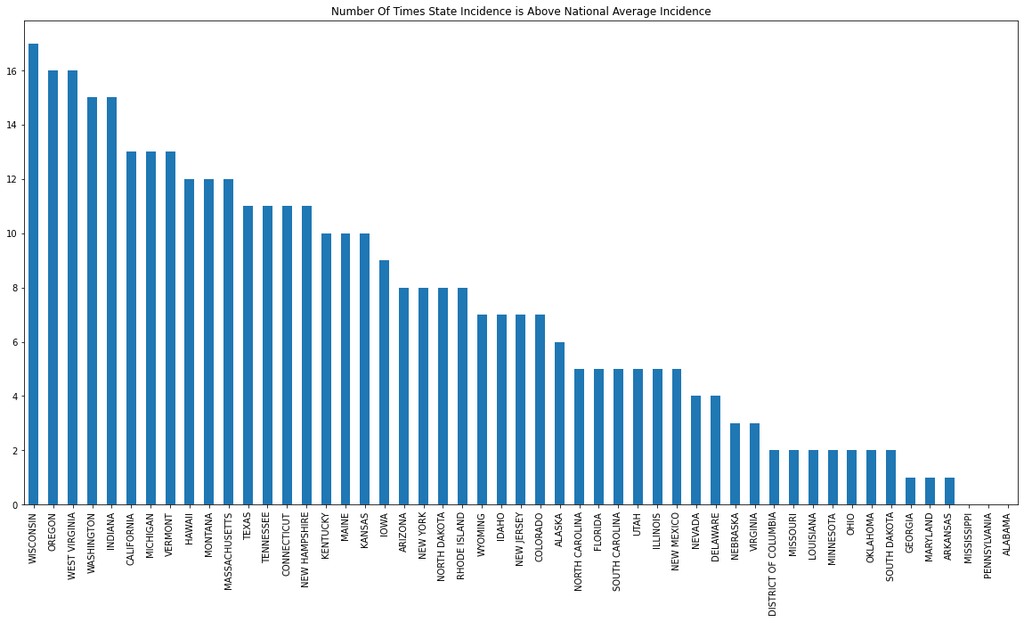

```python
US_state_rubella_incidence = US_state_df(rubella_incidence, states_rubella_incidence)
graph_state_incidence(US_state_rubella_incidence)
```

### Mumps

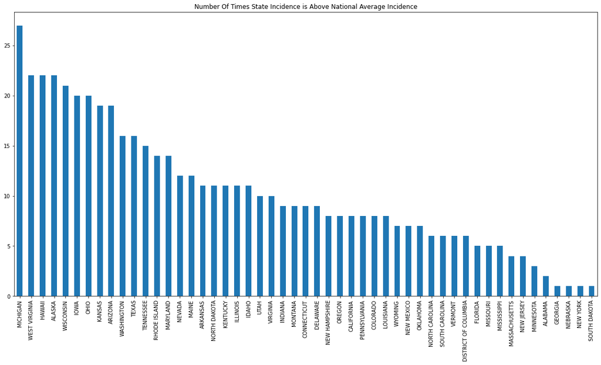

```python
US_state_mumps_incidence = US_state_df(mumps_incidence, states_mumps_incidence)
graph_state_incidence(US_state_mumps_incidence)
```

## Data Collection and Processing (ETL) - Population Density and Income Data

### Population Density

```python
df_density = pd.read_csv("../finalProject/apportionment.csv", sep=",")

df_density.head()

#grab column names for easy transformation
df_density.columns
#['Name', 'Geography Type', 'Year', 'Resident Population',
       #'Percent Change in Resident Population', 'Resident Population Density',
       #'Resident Population Density Rank', 'Number of Representatives',
       #'Change in Number of Representatives',
       #'Average Apportionment Population Per Representative']

#first we need to get rid of the unnecessary information just to make things cleaner
df_density = df_density.drop(columns=['Resident Population', 'Resident Population Density Rank',
                                      'Percent Change in Resident Population',
                                      'Number of Representatives',	'Change in Number of Representatives',
                                      'Average Apportionment Population Per Representative'])
df_density
```

|  | Name | Geography Type | Year | Resident Population Density |
| --- | --- | --- | --- | --- |
| 0 | Alabama | State | 1910 | 42.2 |
| 1 | Alaska | State | 1910 | 0.1 |
| 2 | Arizona | State | 1910 | 1.8 |
| 3 | Arkansas | State | 1910 | 30.3 |
| 4 | California | State | 1910 | 15.3 |
| ... | ... | ... | ... | ... |
| 679 | Midwest Region | Region | 2020 | NaN |
| 680 | Northeast Region | Region | 2020 | NaN |
| 681 | South Region | Region | 2020 | NaN |
| 682 | West Region | Region | 2020 | NaN |
| 683 | United States | Nation | 2020 | 93.8 |

684 rows × 4 columns

There are also some values within the dataframe that we don't need (at least for initial use with our first dataset) such as the regions and the nationwide information. To change this we can just grab the rows with the type "State"

```python
pop_density = df_density[df_density['Geography Type'] == 'State']
pop_density = pop_density.drop(pop_density[pop_density['Name'] == 'Puerto Rico'].index)
pop_density
```

|  | Name | Geography Type | Year | Resident Population Density |
| --- | --- | --- | --- | --- |
| 0 | Alabama | State | 1910 | 42.2 |
| 1 | Alaska | State | 1910 | 0.1 |
| 2 | Arizona | State | 1910 | 1.8 |
| 3 | Arkansas | State | 1910 | 30.3 |
| 4 | California | State | 1910 | 15.3 |
| ... | ... | ... | ... | ... |
| 674 | Virginia | State | 2020 | 218.6 |
| 675 | Washington | State | 2020 | 115.9 |
| 676 | West Virginia | State | 2020 | 74.6 |
| 677 | Wisconsin | State | 2020 | 108.8 |
| 678 | Wyoming | State | 2020 | 5.9 |

612 rows × 4 columns

```python
pop_density[pop_density['Name'] == 'Alabama']
```

|  | Name | Geography Type | Year | Resident Population Density |
| --- | --- | --- | --- | --- |
| 0 | Alabama | State | 1910 | 42.2 |
| 57 | Alabama | State | 1920 | 46.4 |
| 114 | Alabama | State | 1930 | 52.3 |
| 171 | Alabama | State | 1940 | 55.9 |
| 228 | Alabama | State | 1950 | 60.5 |
| 285 | Alabama | State | 1960 | 64.5 |
| 342 | Alabama | State | 1970 | 68 |
| 399 | Alabama | State | 1980 | 76.9 |
| 456 | Alabama | State | 1990 | 79.8 |
| 513 | Alabama | State | 2000 | 87.8 |
| 570 | Alabama | State | 2010 | 94.4 |
| 627 | Alabama | State | 2020 | 99.2 |

```python
#check the datatypes of the dataset
pop_density.dtypes
```

```
Name                           object
Geography Type                 object
Year                            int64
Resident Population Density    object
dtype: object
```

```python
#change the resident population density to a float
pop_density['Resident Population Density'] = pd.to_numeric(pop_density['Resident Population Density'],errors='coerce')

pop_density['Resident Population Density'].describe()
```

```
count    592.000000
mean     122.555912
std      175.061531
min        0.100000
25%       23.450000
50%       56.900000
75%      138.000000
max      974.700000
Name: Resident Population Density, dtype: float64
```

```python
#We also need to make the states uppercase for easu combining later

pop_density['Name'] = pop_density['Name'].str.upper()

pop_density.head()
```

|  | Name | Geography Type | Year | Resident Population Density |
| --- | --- | --- | --- | --- |
| 0 | ALABAMA | State | 1910 | 42.2 |
| 1 | ALASKA | State | 1910 | 0.1 |
| 2 | ARIZONA | State | 1910 | 1.8 |
| 3 | ARKANSAS | State | 1910 | 30.3 |
| 4 | CALIFORNIA | State | 1910 | 15.3 |

The final step to combining this with the initial disease dataset is to ensure that all of the years present in the disease dataset also exist in the population density dataset. This data is grabbed from the census so there are only reports for the 1st year of every decade. While not exact, we can fill in the expected density for each year based on the values provided for each decade. This is done by creating rows for each year and then using interpolate to fill in NaN values by approximating them.

```python
#create list of years needed to fill in the population density data frame
years = list(range(1911, 2020, 1))


years.remove(1920)
years.remove(1930)
years.remove(1940)
years.remove(1950)
years.remove(1960)
years.remove(1970)
years.remove(1980)
years.remove(1990)
years.remove(2000)

years

#itereate over populaiton density to create and fill in a dataframe for each state
states_density = dict()
for k, v in pop_density.groupby('Name'):
  states_density[k] = v
  for year in years:
    states_density[k] = states_density[k].append({'Name':k,	'Geography Type':'State',	'Year':year}, ignore_index=True)
  states_density[k].sort_values(by = 'Year', inplace = True)
```

```python
#use interpolate to approximate population density for each year in each state.
for frame in states_density:
    states_density[frame].interpolate(method='linear', column = 'Resident Population Density', inplace=True)

#As an example for what is being stored, here are 1 DataFrame from states_density
states_density['WISCONSIN']
```

|  | Name | Geography Type | Year | Resident Population Density |
| --- | --- | --- | --- | --- |
| 0 | WISCONSIN | State | 1910 | 43.10 |
| 12 | WISCONSIN | State | 1911 | 43.65 |
| 13 | WISCONSIN | State | 1912 | 44.20 |
| 14 | WISCONSIN | State | 1913 | 44.75 |
| 15 | WISCONSIN | State | 1914 | 45.30 |
| ... | ... | ... | ... | ... |
| 108 | WISCONSIN | State | 2016 | 107.28 |
| 109 | WISCONSIN | State | 2017 | 107.66 |
| 110 | WISCONSIN | State | 2018 | 108.04 |
| 111 | WISCONSIN | State | 2019 | 108.42 |
| 11 | WISCONSIN | State | 2020 | 108.80 |

112 rows × 4 columns

In order to be more workable, we need the state population densities to be in one large dataframe instead of a dictionary of dataframes. We wish to find a correlation between disease incidence and population density.

**We hypothesize that higher population density would indicate a higher incidence as disease can mroe easily spread.**

```python
#put all state population density into one large dataframe
years = states_density['ALABAMA']['Year']
list_of_names = states_density.keys()
res_pop_dens = pd.DataFrame()
for name in list_of_names:
  res_pop_dens[name] = states_density[name]["Resident Population Density"]
res_pop_dens.insert(0, 'Year', years)

#set the index to year for easy accessing
res_pop_dens.set_index('Year', inplace=True)
```

Because we need to find the correlation for every state for every disease, it is best to write a function to calculate and append this information for us

```python
def correlation_function(states, states_disease_incidence, res_pop_dens, name):
  #create empty array to store correlation data
  data = []
  for i in states: #calculates the correlation between incidence of disease and average population density for each state
    data.append(states_disease_incidence[[i]][i].corr(res_pop_dens[[i]][i]))
  #add this data into the larger Dataframe
  correl_density_df[name] = data
```

```python
#Making correlation density dataframes per disease into 1 big dataframe
all_states = res_pop_dens.columns.unique()
correl_density_df = pd.DataFrame(columns = ['Location']) #creating a dataframe of 2 columns
correl_density_df['Location'] = all_states #filling in location with state names

#measles
correlation_function(all_states, states_measles_incidence, res_pop_dens, 'Correlation for Measles')

#Hepatitis A
correlation_function(all_states, states_hepa_incidence, res_pop_dens, 'Correlation for Hepatitis A')

#Mumps
correlation_function(all_states, states_mumps_incidence, res_pop_dens, 'Correlation for Mumps')

#Pertussis
correlation_function(all_states, states_pertussis_incidence, res_pop_dens, 'Correlation for Pertussis')

#Polio
correlation_function(all_states, states_polio_incidence, res_pop_dens, 'Correlation for Polio')

#Rubella
correlation_function(all_states, states_rubella_incidence, res_pop_dens, 'Correlation for Rubella')
correl_density_df.head()
```

|  | Location | Correlation for Measles | Correlation for Hepatitis A | Correlation for Mumps | Correlation for Pertussis | Correlation for Polio | Correlation for Rubella |
| --- | --- | --- | --- | --- | --- | --- | --- |
| 0 | ALABAMA | -0.564066 | -0.862142 | -0.760208 | -0.820631 | -0.042730 | -0.691614 |
| 1 | ALASKA | -0.625996 | -0.430000 | -0.586364 | -0.591051 | -0.411121 | -0.632208 |
| 2 | ARIZONA | -0.556976 | -0.649866 | -0.636456 | -0.783381 | -0.082528 | -0.478183 |
| 3 | ARKANSAS | -0.374926 | -0.700985 | -0.378505 | -0.711537 | 0.159685 | -0.384886 |
| 4 | CALIFORNIA | -0.681544 | -0.894775 | -0.650937 | -0.718160 | -0.214112 | -0.684958 |

```python
#report the maximum and minimum correlation states for measles as well as the average
print('Max correlation for measles: ', correl_density_df['Location'].iloc[correl_density_df['Correlation for Measles'].idxmax()])
print(states_density['WEST VIRGINIA'])
print('Min correlation for measles: ', correl_density_df['Location'].iloc[correl_density_df['Correlation for Measles'].idxmin()])
print(states_density['NEW YORK'])
print('Avg correlation for measles: ', correl_density_df['Correlation for Measles'].mean())
```

```
Max correlation for measles:  WEST VIRGINIA
              Name Geography Type  Year  Resident Population Density
0    WEST VIRGINIA          State  1910                        50.80
12   WEST VIRGINIA          State  1911                        51.81
13   WEST VIRGINIA          State  1912                        52.82
14   WEST VIRGINIA          State  1913                        53.83
15   WEST VIRGINIA          State  1914                        54.84
..             ...            ...   ...                          ...
108  WEST VIRGINIA          State  2016                        75.60
109  WEST VIRGINIA          State  2017                        75.35
110  WEST VIRGINIA          State  2018                        75.10
111  WEST VIRGINIA          State  2019                        74.85
11   WEST VIRGINIA          State  2020                        74.60

[112 rows x 4 columns]
```

[output cut: 16 more lines]

The average correlation between state population and incidence for that state for measles is -.53 which indicates a moderate negative correlation.

**Our hypothesis was disproved** as it would appear that as population density increases, incidence shows a moderate decrease. This could be due to bias on our assumption that all disease spread primarily through close contact with humans as well as an oversimplification of what variables may determine contraction.

The maximum correlation existed for West Virginia, which when compared to the minimum correlation of New York, has a considerably lower average population density. This indicates that perhaps there are other variables at play that may have some slight correlation to population density but do not have the same trends and hence lead to variable correlation values. This could be access to health care and abilty to be diagnosed and treated which can vary widely between states like WV and NY where city centers and population distribution appear very different.

### Income Level

We will attempt to investigate whether average income level by state has any correlation with the disease prevalence by state.

Data source: https://apps.bea.gov/iTable/?reqid=70&step=1&acrdn=2#eyJhcHBpZCI6NzAsInN0ZXBzIjpbMSwyNCwyOSwyNSwzMSwyNiwyNywzMF0s…

This data source comes from the U.S. Bureau of Economic Analysis (BEA). It contains average incomes for each state over the years 1929 to 2021.

```python
income_df = pd.read_csv("../finalProject/income.csv", sep=",", skiprows = 3)
#reading in income file as a dataframe
#we need to skip the first 3 rows because there are some text explanations written in these rows

income_df.head()
#original dataframe
```

|  | GeoFips | GeoName | 1929 | 1930 | 1931 | 1932 | 1933 | 1934 | 1935 | 1936 | ... | 2012 | 2013 | 2014 | 2015 | 2016 | 2017 | 2018 | 2019 | 2020 | 2021 |
| --- | --- | --- | --- | --- | --- | --- | --- | --- | --- | --- | --- | --- | --- | --- | --- | --- | --- | --- | --- | --- | --- |
| 0 | 00000 | United States | 85151.0 | 76394.0 | 65531.0 | 50162.0 | 47114.0 | 53967.0 | 60704.0 | 69063.0 | ... | 14003346.0 | 14189228.0 | 14969527.0 | 15681233.0 | 16092713.0 | 16837337.0 | 17671054.0 | 18575467.0 | 19812171.0 | 21288709.0 |
| 1 | 01000 | Alabama | 843.2 | 697.5 | 583.7 | 421.9 | 435.6 | 556.3 | 586.9 | 683.2 | ... | 173361.7 | 175185.3 | 181078.8 | 189115.4 | 192363.5 | 199191.8 | 206712.0 | 216587.5 | 232040.3 | 250828.8 |
| 2 | 02000 | Alaska * | (NA) | (NA) | (NA) | (NA) | (NA) | (NA) | (NA) | (NA) | ... | 39266.0 | 38978.0 | 41210.0 | 42555.1 | 41837.4 | 42431.4 | 43981.2 | 45056.8 | 45965.1 | 48219.2 |
| 3 | 04000 | Arizona | 257.3 | 224.7 | 184.5 | 137.0 | 131.8 | 154.9 | 180.4 | 204.8 | ... | 237809.1 | 243752.3 | 257272.3 | 270815.5 | 282085.1 | 299249.2 | 316896.3 | 340259.8 | 375601.3 | 403739.3 |
| 4 | 05000 | Arkansas | 560.4 | 416.5 | 381.8 | 278.5 | 283.2 | 341.8 | 386.0 | 460.2 | ... | 107877.3 | 108367.8 | 114743.3 | 118719.5 | 121825.9 | 125285.9 | 130033.4 | 133161.4 | 142038.5 | 153185.8 |

5 rows × 95 columns

**Data Filtering**

We do not have a use for the GeoFips column, which is just the geo-codes corresponding to each state. We also need to get rid of the footnote rows at the bottom of the document.

The datasource notes that estimates prior to 1950 are not available for Alaska and Hawaii.

```python
import numpy as np
income_df
#income_df.drop(income_df[(income_df['GeoFips'] == object)].index, inplace=True)

income_df.drop(income_df.index[list(range(60, 65))], inplace=True)
#We only want to keep the first 60 rows because there are unnecessary lines at the end.

income_df.drop(columns = ["GeoFips"], inplace=True)
#We don't care about the GeoFips column

#We want to change the names that have asterisks to make the data look nicer
index_alaska = income_df.index[income_df['GeoName'] == 'Alaska *'].tolist()[0]
index_hawaii = income_df.index[income_df['GeoName'] == 'Hawaii *'].tolist()[0]
income_df.at[index_alaska, 'GeoName'] = 'Alaska'
income_df.at[index_hawaii, 'GeoName'] = 'Hawaii'

#income_df['GeoName'].loc[income_df['GeoName'].isin(['Alaska *'])] = 'Alaska'
#income_df['GeoName'].loc[income_df['GeoName'].isin(['Hawaii *'])] = 'Hawaii'

income_df.replace('(NA)', np.nan, inplace=True)
#Replacing NA values with NaN

income_df.isnull().sum()[income_df.isnull().sum() > 2]
#Since we know from the data source that 2 states do not have values before 1950, we check to see if there are any other missing values from the other 48 states.
#We see that we return an empty series, so that means only two states had NaN's like we expected.
```

```
Series([], dtype: int64)
```

Now we display the resulting dataset after this cleanup:

```python
income_df.head() #resulting dataset
```

|  | GeoName | 1929 | 1930 | 1931 | 1932 | 1933 | 1934 | 1935 | 1936 | 1937 | ... | 2012 | 2013 | 2014 | 2015 | 2016 | 2017 | 2018 | 2019 | 2020 | 2021 |
| --- | --- | --- | --- | --- | --- | --- | --- | --- | --- | --- | --- | --- | --- | --- | --- | --- | --- | --- | --- | --- | --- |
| 0 | United States | 85151.0 | 76394.0 | 65531.0 | 50162.0 | 47114.0 | 53967.0 | 60704.0 | 69063.0 | 74556.0 | ... | 14003346.0 | 14189228.0 | 14969527.0 | 15681233.0 | 16092713.0 | 16837337.0 | 17671054.0 | 18575467.0 | 19812171.0 | 21288709.0 |
| 1 | Alabama | 843.2 | 697.5 | 583.7 | 421.9 | 435.6 | 556.3 | 586.9 | 683.2 | 733.7 | ... | 173361.7 | 175185.3 | 181078.8 | 189115.4 | 192363.5 | 199191.8 | 206712.0 | 216587.5 | 232040.3 | 250828.8 |
| 2 | Alaska | NaN | NaN | NaN | NaN | NaN | NaN | NaN | NaN | NaN | ... | 39266.0 | 38978.0 | 41210.0 | 42555.1 | 41837.4 | 42431.4 | 43981.2 | 45056.8 | 45965.1 | 48219.2 |
| 3 | Arizona | 257.3 | 224.7 | 184.5 | 137.0 | 131.8 | 154.9 | 180.4 | 204.8 | 229.0 | ... | 237809.1 | 243752.3 | 257272.3 | 270815.5 | 282085.1 | 299249.2 | 316896.3 | 340259.8 | 375601.3 | 403739.3 |
| 4 | Arkansas | 560.4 | 416.5 | 381.8 | 278.5 | 283.2 | 341.8 | 386.0 | 460.2 | 481.6 | ... | 107877.3 | 108367.8 | 114743.3 | 118719.5 | 121825.9 | 125285.9 | 130033.4 | 133161.4 | 142038.5 | 153185.8 |

5 rows × 94 columns

Now we need to complete some transformations to prepare the dataset for analysis.

```python
income_df1 = income_df.set_index('GeoName') #reset index to be by state
income_dfT1 = income_df1.T #transpose
income_dfT1.reset_index(inplace=True) #adding year back as a column to use for plotting
income_dfT1.columns = income_dfT1.columns.str.upper() #need these to be uppercase to join with population density dataset
income_dfT1.rename(columns={'INDEX':'year'}, inplace=True) #renaming column to make more clear
income_dfT1.drop(['NEW ENGLAND', 'MIDEAST', 'GREAT LAKES', 'PLAINS', 'SOUTHEAST', 'SOUTHWEST', 'ROCKY MOUNTAIN', 'FAR WEST'], axis=1, inplace=True) #we want to drop these columns so that they don't mess up any averaging
income_dfT1.head()
```

| GeoName | year | UNITED STATES | ALABAMA | ALASKA | ARIZONA | ARKANSAS | CALIFORNIA | COLORADO | CONNECTICUT | DELAWARE | ... | SOUTH DAKOTA | TENNESSEE | TEXAS | UTAH | VERMONT | VIRGINIA | WASHINGTON | WEST VIRGINIA | WISCONSIN | WYOMING |
| --- | --- | --- | --- | --- | --- | --- | --- | --- | --- | --- | --- | --- | --- | --- | --- | --- | --- | --- | --- | --- | --- |
| 0 | 1929 | 85151.0 | 843.2 | NaN | 257.3 | 560.4 | 5495.5 | 635.6 | 1640.5 | 243.4 | ... | 286.2 | 971.2 | 2728.7 | 278.2 | 226.3 | 1054.5 | 1150.5 | 787.4 | 1966.8 | 149.9 |
| 1 | 1930 | 76394.0 | 697.5 | NaN | 224.7 | 416.5 | 5079.4 | 596.8 | 1494.7 | 205.1 | ... | 247.3 | 841.9 | 2381.2 | 251.6 | 206.0 | 938.4 | 1030.7 | 706.1 | 1724.7 | 131.6 |
| 2 | 1931 | 65531.0 | 583.7 | NaN | 184.5 | 381.8 | 4387.5 | 498.5 | 1313.1 | 187.7 | ... | 167.8 | 724.9 | 2038.5 | 190.8 | 169.2 | 906.9 | 844.7 | 616.3 | 1402.6 | 109.3 |
| 3 | 1932 | 50162.0 | 421.9 | NaN | 137.0 | 278.5 | 3441.4 | 380.3 | 1026.9 | 144.9 | ... | 130.9 | 526.2 | 1560.7 | 157.4 | 129.9 | 701.9 | 637.4 | 448.2 | 1094.0 | 86.4 |
| 4 | 1933 | 47114.0 | 435.6 | NaN | 131.8 | 283.2 | 3277.3 | 378.4 | 970.3 | 140.4 | ... | 93.9 | 552.6 | 1530.0 | 154.6 | 120.4 | 704.4 | 598.8 | 453.0 | 1014.1 | 85.5 |

5 rows × 53 columns

We need to check that the datatypes are correct.

```python
income_dfT1.dtypes
```

```
GeoName
year                    object
UNITED STATES           object
ALABAMA                 object
ALASKA                  object
ARIZONA                 object
ARKANSAS                object
CALIFORNIA              object
COLORADO                object
CONNECTICUT             object
DELAWARE                object
DISTRICT OF COLUMBIA    object
FLORIDA                 object
GEORGIA                 object
HAWAII                  object
IDAHO                   object
ILLINOIS                object
INDIANA                 object
IOWA                    object
KANSAS                  object
KENTUCKY                object
LOUISIANA               object
MAINE                   object
MARYLAND                object
MASSACHUSETTS           object
MICHIGAN                object
MINNESOTA               object
MISSISSIPPI             object
MISSOURI                object
MONTANA                 object
NEBRASKA                object
NEVADA                  object
NEW HAMPSHIRE           object
NEW JERSEY              object
NEW MEXICO              object
NEW YORK                object
NORTH CAROLINA          object
NORTH DAKOTA            object
OHIO                    object
OKLAHOMA                object
OREGON                  object
PENNSYLVANIA            object
RHODE ISLAND            object
SOUTH CAROLINA          object
SOUTH DAKOTA            object
TENNESSEE               object
TEXAS                   object
UTAH                    object
VERMONT                 object
VIRGINIA                object
WASHINGTON              object
WEST VIRGINIA           object
WISCONSIN               object
WYOMING                 object
dtype: object
```

Oops! These are all objects, when we expect integers for years and floats for the income amounts.

```python
cols_income = income_dfT1.columns
income_dfT1[cols_income] = income_dfT1[cols_income].apply(pd.to_numeric, errors='coerce') #changing datatypes from objects to floats/integers where appropriate

income_dfT1['ARIZONA'] #checking datatype
```

```
0        257.3
1        224.7
2        184.5
3        137.0
4        131.8
        ...
88    299249.2
89    316896.3
90    340259.8
91    375601.3
92    403739.3
Name: ARIZONA, Length: 93, dtype: float64
```

```python
income_dfT1.dtypes
```

```
GeoName
year                      int64
UNITED STATES           float64
ALABAMA                 float64
ALASKA                  float64
ARIZONA                 float64
ARKANSAS                float64
CALIFORNIA              float64
COLORADO                float64
CONNECTICUT             float64
DELAWARE                float64
DISTRICT OF COLUMBIA    float64
FLORIDA                 float64
GEORGIA                 float64
HAWAII                  float64
IDAHO                   float64
ILLINOIS                float64
INDIANA                 float64
IOWA                    float64
KANSAS                  float64
KENTUCKY                float64
LOUISIANA               float64
MAINE                   float64
MARYLAND                float64
MASSACHUSETTS           float64
MICHIGAN                float64
MINNESOTA               float64
MISSISSIPPI             float64
MISSOURI                float64
MONTANA                 float64
NEBRASKA                float64
NEVADA                  float64
NEW HAMPSHIRE           float64
NEW JERSEY              float64
NEW MEXICO              float64
NEW YORK                float64
NORTH CAROLINA          float64
NORTH DAKOTA            float64
OHIO                    float64
OKLAHOMA                float64
OREGON                  float64
PENNSYLVANIA            float64
RHODE ISLAND            float64
SOUTH CAROLINA          float64
SOUTH DAKOTA            float64
TENNESSEE               float64
TEXAS                   float64
UTAH                    float64
VERMONT                 float64
VIRGINIA                float64
WASHINGTON              float64
WEST VIRGINIA           float64
WISCONSIN               float64
WYOMING                 float64
dtype: object
```

Great! All fixed to be as expected.

**Analysis**

Now we plot income level by state over time just to get a quick visual of the data.

We only plot the max 7 states because 50 states would give us a whacky legend and a difficult graph to read.

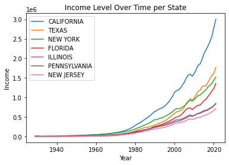

```python
#We sort the max income values series in descending order to grab the max 7 states, and then grab the names of those states
income_dfT1.max().sort_values(axis=0, ascending=False)[1:8].index.tolist() #Rows 0 is the United States, but we only want the max 10 states

#Then we plot
income_dfT1.plot(x = 'year', y=income_dfT1.max().sort_values(axis=0, ascending=False)[1:8].index.tolist())
plt.legend(income_dfT1.max().sort_values(axis=0, ascending=False)[1:8].index.tolist());
plt.title("Income Level Over Time per State")
plt.xlabel('Year')
plt.ylabel('Income')
```

The above plot is just useful to note that income generally increased extremely over time for each state, and it is evident that some states have significantly more average income than others, such as California.

It is important to note that the cost of living is not the same in each state as well.

```python
income_dfT1.set_index('year', inplace=True)
income_dfT1.head()
```

| GeoName year | UNITED STATES | ALABAMA | ALASKA | ARIZONA | ARKANSAS | CALIFORNIA | COLORADO | CONNECTICUT | DELAWARE | DISTRICT OF COLUMBIA | ... | SOUTH DAKOTA | TENNESSEE | TEXAS | UTAH | VERMONT | VIRGINIA | WASHINGTON | WEST VIRGINIA | WISCONSIN | WYOMING |
| --- | --- | --- | --- | --- | --- | --- | --- | --- | --- | --- | --- | --- | --- | --- | --- | --- | --- | --- | --- | --- | --- |
| 1929 | 85151.0 | 843.2 | NaN | 257.3 | 560.4 | 5495.5 | 635.6 | 1640.5 | 243.4 | 639.3 | ... | 286.2 | 971.2 | 2728.7 | 278.2 | 226.3 | 1054.5 | 1150.5 | 787.4 | 1966.8 | 149.9 |
| 1930 | 76394.0 | 697.5 | NaN | 224.7 | 416.5 | 5079.4 | 596.8 | 1494.7 | 205.1 | 641.4 | ... | 247.3 | 841.9 | 2381.2 | 251.6 | 206.0 | 938.4 | 1030.7 | 706.1 | 1724.7 | 131.6 |
| 1931 | 65531.0 | 583.7 | NaN | 184.5 | 381.8 | 4387.5 | 498.5 | 1313.1 | 187.7 | 631.7 | ... | 167.8 | 724.9 | 2038.5 | 190.8 | 169.2 | 906.9 | 844.7 | 616.3 | 1402.6 | 109.3 |
| 1932 | 50162.0 | 421.9 | NaN | 137.0 | 278.5 | 3441.4 | 380.3 | 1026.9 | 144.9 | 567.9 | ... | 130.9 | 526.2 | 1560.7 | 157.4 | 129.9 | 701.9 | 637.4 | 448.2 | 1094.0 | 86.4 |
| 1933 | 47114.0 | 435.6 | NaN | 131.8 | 283.2 | 3277.3 | 378.4 | 970.3 | 140.4 | 500.2 | ... | 93.9 | 552.6 | 1530.0 | 154.6 | 120.4 | 704.4 | 598.8 | 453.0 | 1014.1 | 85.5 |

5 rows × 52 columns

```python
all_states = states_measles_incidence.columns.unique() #grabbing the names of all the states
```

We wish to explore the relationship between incidence and average income per state.

We can calculate the correlation of the two for each state over all of the years that we have data available for, for each disease separately.

```python
correl_income_df = pd.DataFrame(columns = ['Location']) #creating a dataframe of 2 columns
correl_income_df['Location'] = all_states #filling in location with state names

incidences = [states_measles_incidence, states_hepa_incidence, states_mumps_incidence, states_pertussis_incidence, states_polio_incidence, states_rubella_incidence, states_smallpox_incidence]

#Creating a function to automate the process of iterating through each disease
def correl_income_df_func(incidence, dis_name):
  meas_corr_data_func = []
  for i in all_states: #calculates the correlation between incidence of measles and average income of the state and appends to an array which we will throw into the dataframe later
    meas_corr_data_func.append(incidence[[i]][i].corr(income_dfT1[[i]][i]))
  correl_income_df[f'Correlation for {dis_name}'] = meas_corr_data_func #Creating a new column for this disease and throw in the correlation data

#Filling in the resultant correlation dataframe
correl_income_df_func(states_measles_incidence, 'Measles')
correl_income_df_func(states_hepa_incidence, 'Hepatitis A')
correl_income_df_func(states_mumps_incidence, 'Mumps')
correl_income_df_func(states_pertussis_incidence, 'Pertussis')
correl_income_df_func(states_polio_incidence, 'Polio')
correl_income_df_func(states_rubella_incidence, 'Rubella')

correl_income_df
```

|  | Location | Correlation for Measles | Correlation for Hepatitis A | Correlation for Mumps | Correlation for Pertussis | Correlation for Polio | Correlation for Rubella |
| --- | --- | --- | --- | --- | --- | --- | --- |
| 0 | ALABAMA | -0.438864 | -0.787450 | -0.673812 | -0.619376 | -0.182555 | -0.553569 |
| 1 | ALASKA | -0.504059 | -0.421837 | -0.557576 | -0.223854 | -0.281991 | -0.580474 |
| 2 | ARIZONA | -0.471913 | -0.687155 | -0.526443 | -0.605962 | -0.138901 | -0.372119 |
| 3 | ARKANSAS | -0.374091 | -0.685318 | -0.443986 | -0.603096 | 0.024448 | -0.342586 |
| 4 | CALIFORNIA | -0.491681 | -0.840580 | -0.561661 | -0.494432 | -0.292186 | -0.597785 |
| 5 | COLORADO | -0.473118 | -0.790049 | -0.520779 | -0.477964 | -0.030515 | -0.475452 |
| 6 | CONNECTICUT | -0.494054 | -0.676581 | -0.587232 | -0.566260 | -0.196509 | -0.491188 |
| 7 | DELAWARE | -0.352530 | -0.691063 | -0.706025 | -0.448722 | 0.016508 | -0.387056 |
| 8 | DISTRICT OF COLUMBIA | -0.430254 | -0.381729 | -0.315241 | -0.562689 | -0.055079 | -0.272922 |
| 9 | FLORIDA | -0.393899 | -0.701293 | -0.611818 | -0.532889 | 0.012449 | -0.530016 |
| 10 | GEORGIA | -0.320447 | -0.688778 | -0.263598 | -0.559281 | -0.015368 | -0.351515 |
| 11 | HAWAII | -0.444390 | -0.669737 | -0.517535 | -0.203510 | -0.416792 | -0.426629 |
| 12 | IDAHO | -0.460630 | -0.692686 | -0.566743 | -0.471422 | 0.077795 | -0.487007 |
| 13 | ILLINOIS | -0.471243 | -0.758112 | -0.707377 | -0.510833 | -0.119096 | -0.629050 |
| 14 | INDIANA | -0.471012 | -0.784077 | -0.626504 | -0.644863 | -0.023369 | -0.595665 |
| 15 | IOWA | -0.418800 | -0.603993 | -0.603113 | -0.464908 | 0.149623 | -0.573497 |
| 16 | KANSAS | -0.466032 | -0.741988 | -0.662507 | -0.538337 | 0.096425 | -0.429905 |
| 17 | KENTUCKY | -0.439927 | -0.750518 | -0.641025 | -0.635103 | 0.041686 | -0.559005 |
| 18 | LOUISIANA | -0.447005 | -0.810822 | -0.254834 | -0.463114 | 0.056014 | -0.485844 |
| 19 | MAINE | -0.479206 | -0.516104 | -0.567805 | -0.633887 | -0.046865 | -0.556266 |
| 20 | MARYLAND | -0.383021 | -0.663977 | -0.563129 | -0.560587 | -0.059396 | -0.474399 |
| 21 | MASSACHUSETTS | -0.553791 | -0.489817 | -0.459569 | -0.559990 | -0.107367 | -0.560347 |
| 22 | MICHIGAN | -0.500868 | -0.737273 | -0.675314 | -0.609570 | -0.119926 | -0.729918 |
| 23 | MINNESOTA | -0.373499 | -0.697321 | -0.530679 | -0.444325 | -0.070244 | -0.499605 |
| 24 | MISSISSIPPI | -0.377433 | -0.732160 | -0.561017 | -0.385160 | 0.055086 | -0.373902 |
| 25 | MISSOURI | -0.439282 | -0.600504 | -0.655783 | -0.521782 | 0.021800 | -0.447154 |
| 26 | MONTANA | -0.500560 | -0.726915 | -0.627714 | -0.438677 | 0.012123 | -0.584399 |
| 27 | NEBRASKA | -0.398446 | -0.537230 | -0.632497 | -0.498075 | 0.176869 | -0.289057 |
| 28 | NEVADA | -0.312422 | -0.669026 | -0.402603 | -0.305455 | 0.116253 | -0.503912 |
| 29 | NEW HAMPSHIRE | -0.384313 | -0.542423 | -0.553658 | -0.561887 | 0.138748 | -0.474458 |
| 30 | NEW JERSEY | -0.519256 | -0.699206 | -0.600998 | -0.593741 | -0.213640 | -0.563064 |
| 31 | NEW MEXICO | -0.452374 | -0.796322 | -0.514237 | -0.517054 | -0.087182 | -0.526129 |
| 32 | NEW YORK | -0.575878 | -0.654657 | -0.635314 | -0.550308 | -0.229062 | -0.525775 |
| 33 | NORTH CAROLINA | -0.316167 | -0.606512 | -0.338804 | -0.457097 | -0.043573 | -0.249987 |
| 34 | NORTH DAKOTA | -0.433816 | -0.499573 | -0.555261 | -0.477584 | 0.070357 | -0.664824 |
| 35 | OHIO | -0.500542 | -0.804153 | -0.703410 | -0.555504 | -0.090723 | -0.687021 |
| 36 | OKLAHOMA | -0.422502 | -0.475569 | -0.528256 | -0.584851 | -0.033737 | -0.382634 |
| 37 | OREGON | -0.523861 | -0.796372 | -0.553439 | -0.599129 | 0.101379 | -0.675984 |
| 38 | PENNSYLVANIA | -0.490885 | -0.650329 | -0.602147 | -0.572429 | -0.132532 | -0.438337 |
| 39 | RHODE ISLAND | -0.394296 | -0.617608 | -0.605285 | -0.621437 | 0.111882 | -0.334214 |
| 40 | SOUTH CAROLINA | -0.392597 | -0.645628 | -0.478741 | -0.499401 | -0.039939 | -0.537443 |
| 41 | SOUTH DAKOTA | -0.265881 | -0.321733 | -0.391740 | -0.422224 | 0.151902 | 0.120758 |
| 42 | TENNESSEE | -0.398904 | -0.701850 | -0.613782 | -0.597027 | 0.003533 | -0.582133 |
| 43 | TEXAS | -0.452337 | -0.842644 | -0.603819 | -0.575867 | 0.044653 | -0.408034 |
| 44 | UTAH | -0.353990 | -0.652629 | -0.518282 | -0.423923 | 0.116972 | -0.612660 |
| 45 | VERMONT | -0.401079 | -0.493054 | -0.474270 | -0.595264 | -0.091076 | -0.390664 |
| 46 | VIRGINIA | -0.473576 | -0.611603 | -0.616531 | -0.568281 | -0.071741 | -0.546190 |
| 47 | WASHINGTON | -0.518176 | -0.715003 | -0.589229 | -0.436118 | -0.179919 | -0.477765 |
| 48 | WEST VIRGINIA | -0.513411 | -0.737397 | -0.782945 | -0.668567 | 0.002412 | -0.677053 |
| 49 | WISCONSIN | -0.547927 | -0.723717 | -0.628660 | -0.543277 | 0.078701 | -0.739234 |
| 50 | WYOMING | -0.391032 | -0.619877 | -0.521698 | -0.547756 | 0.161935 | -0.331384 |

This makes sense because this is saying that for a higher income, the chances of contracting measles is less. Vice versa, for a lower income, the chances of contracting measles is higher. This does not establish causality, but it certainly displays an expected relationship!

Now we can compute some stats about our table.

```python
print('Max correlation for measles: ', correl_income_df['Location'].iloc[correl_income_df['Correlation for Measles'].idxmax()])
print('Min correlation for measles: ', correl_income_df['Location'].iloc[correl_income_df['Correlation for Measles'].idxmin()])
print('Avg correlation for measles: ', correl_income_df['Correlation for Measles'].mean())
```

```
Max correlation for measles:  SOUTH DAKOTA
Min correlation for measles:  NEW YORK
Avg correlation for measles:  -0.4393191688736428
```

It is interesting to point out that the average correlation over all of the states for the entire period for measles is just under 50%.

We note that we know we cannot make strong claims on this data because income also varies between state based on average living costs.

In addition, we recognize it would have been better to have data for income level of each person who got sick since this income set is just the average income of the state including people who aren't sick. This is just to explore a relationship between overall state wealth and illness.

We can compute these stats for the other diseases too.

## Analysis, Hypothesis Testing, & ML - Predictive Models

Our idea for a predictive model is to create a hypothetical situation and predict the chances that someone in a particular state would contract a certain disease in a couple of years after.

For instance, we could say, "Imagine you are living in Louisiana in 1955, and you want to know the chances of you catching Measles in 1967."

The independent variables used to train the model would be the year, state, disease, and income level and the dependent variable to be predicted on would be the probability that this person will contract the disease at hand.

In order to perform a more robust analysis, we can determine the effects of certain factors on our predictive model. For instance, we can test whether splitting the data differently or taking out certain features improves the error of our model.

### Preparing a Dataframe for Modeling

We need to do a quick operation to prepare the income dataset with the disease incidence tables.

```python
#removing unnecessary columns from income
income_dfT1.drop(income_dfT1.loc[2012:].index, inplace=True)
income_dfT1.drop(columns=['UNITED STATES'], inplace=True)
income_dfT1
```

| GeoName year | ALABAMA | ALASKA | ARIZONA | ARKANSAS | CALIFORNIA | COLORADO | CONNECTICUT | DELAWARE | DISTRICT OF COLUMBIA | FLORIDA | ... | SOUTH DAKOTA | TENNESSEE | TEXAS | UTAH | VERMONT | VIRGINIA | WASHINGTON | WEST VIRGINIA | WISCONSIN | WYOMING |
| --- | --- | --- | --- | --- | --- | --- | --- | --- | --- | --- | --- | --- | --- | --- | --- | --- | --- | --- | --- | --- | --- |
| 1929 | 843.2 | NaN | 257.3 | 560.4 | 5495.5 | 635.6 | 1640.5 | 243.4 | 639.3 | 749.9 | ... | 286.2 | 971.2 | 2728.7 | 278.2 | 226.3 | 1054.5 | 1150.5 | 787.4 | 1966.8 | 149.9 |
| 1930 | 697.5 | NaN | 224.7 | 416.5 | 5079.4 | 596.8 | 1494.7 | 205.1 | 641.4 | 688.0 | ... | 247.3 | 841.9 | 2381.2 | 251.6 | 206.0 | 938.4 | 1030.7 | 706.1 | 1724.7 | 131.6 |
| 1931 | 583.7 | NaN | 184.5 | 381.8 | 4387.5 | 498.5 | 1313.1 | 187.7 | 631.7 | 592.6 | ... | 167.8 | 724.9 | 2038.5 | 190.8 | 169.2 | 906.9 | 844.7 | 616.3 | 1402.6 | 109.3 |
| 1932 | 421.9 | NaN | 137.0 | 278.5 | 3441.4 | 380.3 | 1026.9 | 144.9 | 567.9 | 482.4 | ... | 130.9 | 526.2 | 1560.7 | 157.4 | 129.9 | 701.9 | 637.4 | 448.2 | 1094.0 | 86.4 |
| 1933 | 435.6 | NaN | 131.8 | 283.2 | 3277.3 | 378.4 | 970.3 | 140.4 | 500.2 | 448.4 | ... | 93.9 | 552.6 | 1530.0 | 154.6 | 120.4 | 704.4 | 598.8 | 453.0 | 1014.1 | 85.5 |
| ... | ... | ... | ... | ... | ... | ... | ... | ... | ... | ... | ... | ... | ... | ... | ... | ... | ... | ... | ... | ... | ... |
| 2007 | 152984.4 | 29869.1 | 221244.8 | 89170.5 | 1572721.4 | 202115.9 | 203467.2 | 36380.4 | 34363.2 | 727260.7 | ... | 30673.9 | 210986.9 | 883810.4 | 86153.1 | 24280.9 | 342962.7 | 276678.4 | 54490.8 | 212179.2 | 24752.8 |
| 2008 | 158450.6 | 32907.7 | 224508.3 | 92864.7 | 1594742.5 | 210029.4 | 216174.5 | 36145.2 | 35329.0 | 729994.1 | ... | 32898.7 | 219027.3 | 971051.2 | 90386.9 | 25603.9 | 356536.0 | 290319.4 | 58167.1 | 220311.5 | 27163.2 |
| 2009 | 155913.5 | 33028.4 | 212646.0 | 91170.8 | 1540872.6 | 199351.6 | 212582.6 | 36432.9 | 35618.5 | 686755.8 | ... | 31893.7 | 217218.6 | 924343.9 | 86761.6 | 25291.7 | 349428.5 | 277305.3 | 58608.6 | 216466.3 | 24949.2 |
| 2010 | 162531.1 | 35452.0 | 216873.6 | 94576.1 | 1614040.8 | 205866.1 | 221058.5 | 36837.8 | 38324.4 | 732457.5 | ... | 33804.0 | 227883.0 | 985165.1 | 89439.2 | 26140.0 | 365245.5 | 285579.9 | 60753.8 | 222982.7 | 26328.8 |
| 2011 | 168474.3 | 37981.8 | 227700.1 | 100739.2 | 1715227.0 | 223492.6 | 226907.1 | 39925.0 | 41395.0 | 771409.5 | ... | 36842.8 | 241617.6 | 1077403.3 | 96356.7 | 27690.6 | 385984.5 | 302075.9 | 64227.3 | 235433.8 | 28786.6 |

83 rows × 51 columns

We make our large dataset that contains all of our data - year, state, income, incidence of each disease, and population density.

```python
from itertools import product
copy = income_dfT1
tuples = list(product(copy.index, copy.columns)) #creating all possible combinations
tuples

index = pd.MultiIndex.from_tuples(tuples, names=["year", "state"]) #creating multiindex to use in new datafra,e
altogether = pd.DataFrame(index=index, columns=['Income']) #creating empty dataframe to later fill in values for

#Adding in income into total dataframe
for i in income_dfT1: #states - cols
  for j in income_dfT1.index: #years - rows
    altogether.at[(j, i), 'Income'] = income_dfT1.loc[j, i]

#Creating a function that adds each disease incidence dataframe to total dataframe
def add_disease_inc(df, name):
  for i in df: #states - cols
    for j in df.index: #years - rows
      altogether.at[(j, i), f'{name}'] = df.loc[j, i]
#Calling function for each disease
add_disease_inc(states_measles_incidence, 'Measles Incidence')
add_disease_inc(states_mumps_incidence, 'Mumps Incidence')
add_disease_inc(states_hepa_incidence, 'Hep-A Incidence')
add_disease_inc(states_pertussis_incidence, 'Pertussis Incidence')
add_disease_inc(states_polio_incidence, 'Polio Incidence')
add_disease_inc(states_rubella_incidence, 'Rubella Incidence')
add_disease_inc(states_smallpox_incidence, 'Smallpox Incidence')

#Creating dataframe of population densities
d = { k: v.set_index(['Year', 'Name']) for k, v in states_density.items()} #setting index to Year and Name for every dataframe within the dictionary states_density
df_densities = pd.concat(d, axis=0) #putting all of the dataframes into 1 dataframe
df_densities.reset_index(inplace = True)
df_densities.set_index(['Year', 'Name'], inplace=True)
df_densities

#Merging population density dataframe with big dataframe
altogether = altogether.merge(df_densities, left_index=True, right_on=['Year', 'Name'])
altogether.drop(columns= ['level_0', 'Geography Type'], inplace=True) #Don't need these columns
altogether.rename(columns={"Resident Population Density": "Pop Density"}, inplace=True)

#Sorting in order and making year and state name individual columns
altogether.sort_index(inplace=True, ascending=True)
altogether.reset_index(inplace=True)

altogether
```

|  | Year | Name | Income | Measles Incidence | Mumps Incidence | Hep-A Incidence | Pertussis Incidence | Polio Incidence | Rubella Incidence | Smallpox Incidence | Pop Density |
| --- | --- | --- | --- | --- | --- | --- | --- | --- | --- | --- | --- |
| 0 | 1928 | ALABAMA | NaN | 0.003350 | NaN | NaN | NaN | 0.000023 | NaN | 0.000129 | 51.12 |
| 1 | 1928 | ALASKA | NaN | NaN | NaN | NaN | NaN | NaN | NaN | NaN | 0.10 |
| 2 | 1928 | ARIZONA | NaN | 0.002007 | NaN | NaN | NaN | 0.000026 | NaN | 0.000972 | 3.62 |
| 3 | 1928 | ARKANSAS | NaN | 0.004818 | NaN | NaN | NaN | 0.000005 | NaN | 0.000134 | 35.22 |
| 4 | 1928 | CALIFORNIA | NaN | 0.000692 | NaN | NaN | NaN | 0.000051 | NaN | 0.000185 | 33.52 |
| ... | ... | ... | ... | ... | ... | ... | ... | ... | ... | ... | ... |
| 4330 | 2011 | VIRGINIA | 385984.5 | NaN | NaN | 3.211223e-06 | 0.000021 | NaN | NaN | NaN | 204.20 |
| 4331 | 2011 | WASHINGTON | 302075.9 | NaN | NaN | 4.099538e-06 | 0.000107 | NaN | NaN | NaN | 102.67 |
| 4332 | 2011 | WEST VIRGINIA | 64227.3 | NaN | NaN | 2.155911e-06 | 0.000020 | NaN | NaN | NaN | 76.85 |
| 4333 | 2011 | WISCONSIN | 235433.8 | NaN | NaN | 8.753858e-07 | 0.000061 | NaN | NaN | NaN | 105.38 |
| 4334 | 2011 | WYOMING | 28786.6 | NaN | NaN | 1.760074e-06 | 0.000012 | NaN | NaN | NaN | 5.81 |

4335 rows × 11 columns

Now, we examine only the case of measles to make things simpler, and keep in mind that we can examine any disease.

Additionally, we will drop any nans here as any data at this point such as the disease incidence can not be linearly interpolated without potentially skewing and creating false trends.

```python
#Create shorter version of altogether dataframe
measles_together = altogether.drop(columns=['Mumps Incidence', 'Hep-A Incidence', 'Pertussis Incidence', 'Polio Incidence', 'Rubella Incidence', 'Smallpox Incidence'])

#Drop nans
measles_together.dropna(inplace=True)

#Reset index after drop
measles_together.reset_index(inplace=True)
measles_together.drop(columns=['index'], inplace=True)

measles_together
```

|  | Year | Name | Income | Measles Incidence | Pop Density |
| --- | --- | --- | --- | --- | --- |
| 0 | 1929 | ALABAMA | 843.2 | 1.119138e-03 | 51.710000 |
| 1 | 1929 | ARIZONA | 257.3 | 5.488372e-04 | 3.710000 |
| 2 | 1929 | ARKANSAS | 560.4 | 6.722462e-04 | 35.410000 |
| 3 | 1929 | CALIFORNIA | 5495.5 | 7.275357e-04 | 34.960000 |
| 4 | 1929 | COLORADO | 635.6 | 7.420635e-04 | 9.910000 |
| ... | ... | ... | ... | ... | ... |
| 2944 | 2002 | NEVADA | 69843.2 | 0.000000e+00 | 19.363636 |
| 2945 | 2002 | NEW YORK | 709785.0 | 5.218697e-08 | 404.245455 |
| 2946 | 2002 | OHIO | 338738.3 | 0.000000e+00 | 278.618182 |
| 2947 | 2002 | TEXAS | 640381.6 | 4.606005e-08 | 82.800000 |
| 2948 | 2002 | UTAH | 58562.9 | 0.000000e+00 | 28.363636 |

2949 rows × 5 columns

### Predictor 1 - Split Data in Half

We can create a predictor for measles that just splits the data in half.

With this predictor, we expect that our predicted incidence value will be much higher than in actuality because we have to predict on a year just after the vaccine came out- this is a piece of information that our model does not have nor is it trained to account for.

First, we split the data in half. Then, we define our features to train on as the year, state, income, and population density.

We can use a for loop to test out different k values to use for our k-nearest neighbors model and get a validation error.

```python
#JUST MEASLES PREDICTOR
from pandas.core.dtypes.cast import maybe_unbox_datetimelike_tz_deprecation
from sklearn.feature_extraction import DictVectorizer
from sklearn.preprocessing import StandardScaler

# Fit model to data
from sklearn.neighbors import KNeighborsRegressor

# split data in half
# There are 2949 rows in measles_together, so 2949/2 = 1474.5
train = measles_together.iloc[0:1475]
val = measles_together.iloc[1475:]

# defining features
features = ["Year",
            "Name",
            "Income",
            "Pop Density"]

X_train_dict = train[features].to_dict(orient="records")
X_val_dict = val[features].to_dict(orient="records")

y_train = train["Measles Incidence"]
y_val = val["Measles Incidence"]

#For loop to determine optimal k to use
k_1 = [i for i in range(1,100)]
error_results = []
for i in k_1:
  def get_val_error(X_train_dict, y_train, X_val_dict, y_val, i):
    # convert categorical variables to dummy variables
    vec = DictVectorizer(sparse=False)
    vec.fit(X_train_dict)
    X_train = vec.transform(X_train_dict)
    X_val = vec.transform(X_val_dict)

    # standardize the data
    scaler = StandardScaler()
    scaler.fit(X_train)
    X_train_sc = scaler.transform(X_train)
    X_val_sc = scaler.transform(X_val)

    # Fit a 10-nearest neighbors model.
    model = KNeighborsRegressor(n_neighbors=i)
    model.fit(X_train_sc, y_train)

    # Make predictions on the validation set.
    y_val_pred = model.predict(X_val_sc)
    rmse = np.sqrt(((y_val - y_val_pred) ** 2).mean())

    return rmse

  val1 = get_val_error(X_train_dict, y_train, X_val_dict, y_val, i)
  val2 = get_val_error(X_val_dict, y_val, X_train_dict, y_train, i) #reverse
  cross_val = (val1 + val2)/2
  error_results.append(cross_val)
```

We plot these k values and the corresponding errors they give to determine the best k to use.

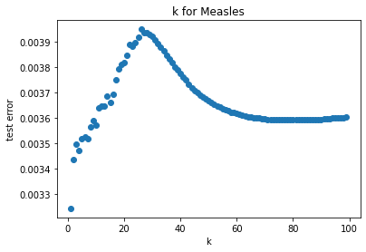

```python
#Plotting k with validation error
import matplotlib.pyplot as plt
plt.scatter(x=k_1, y=error_results)
plt.xlabel('k')
plt.ylabel('test error')
plt.title('k for Measles')
ymin = min(error_results)
#xpos = np.where(error_results == ymin)
#xmin = xpos[0][0]
#print('xmin = ', xmin)
```

We don't want to pick a k too close to 0, because this error is too good to be true since we would be picking data points too similar to the one we are predicting for.

Next, we take this k and make our predictions.

```python
# Use k=57 to predict
# convert categorical variables to dummy variables
vec = DictVectorizer(sparse=False)
vec.fit(X_train_dict)
X_train = vec.transform(X_train_dict)
X_val = vec.transform(X_val_dict)

# standardize the data
scaler = StandardScaler()
scaler.fit(X_train)
X_train_sc = scaler.transform(X_train)
X_val_sc = scaler.transform(X_val)

# Fit a 57-nearest neighbors model.
model = KNeighborsRegressor(n_neighbors=57)
model.fit(X_train_sc, y_train)

# Make predictions on the validation set.
y_val_pred = model.predict(X_val_sc)
rmse = np.sqrt(((y_val - y_val_pred) ** 2).mean())

#print(y_val_pred)
print('val error: ', ymin)
```

```
val error:  0.0032435563716947326
```

If we want to know the chances of catching measles in 1970 in Alabama, we need to find the index of this datapoint in the dataframe we predicted on and map it to its index in our resulting prediction dataframe

```python
val[val['Year'] == 1970]
#Find that 1970 ALabama is at index 1967

#1967 - 1475 = 492 gives us the index in the predicted array
y_val_pred[492]
```

```
0.002460425878952384
```

If I want to know the chances of catching measles in 1970 in Alabama, the results show that the incidence is 0.002460425878952384.

The expected value is 0.000139. It makes sense that the obtained and expected values are off because we were predicting on a year right after the measles vaccine came out, and the incidence values drastically drop off at this point.

```python
#Calculate percent error
#Percentage Error = ((Estimated Number - Actual Number)/ Actual number) x 100
((.002460425878952384 - .000139)/ .000139) * 100
```

```
1670.090560397399
```

The percent error here is 1670%! Let's see if we can reduce this.

### Predictor 2 - Splitting the Data Into Quarters

Now, to examine another way of splitting the data, we can split the data into about quarters and only examine the times that the diseases were prevalent before vaccine release. We predict that our predicted incidence value will be closer to the expected than in Model 1.

Specifically for measles, the vaccine was released in 1963. So we want to examine measles incidence from 1929 to 1963 instead of 1929 to 2002 in order to give our model a better shot of actively predicting.

In order to figure out which indices to use from measles_together, we can see the last index where we have data for the year 1963.

```python
measles_together[measles_together['Year'] == 1963].tail()
```

|  | Year | Name | Income | Measles Incidence | Pop Density |
| --- | --- | --- | --- | --- | --- |
| 1665 | 1963 | VIRGINIA | 10106.6 | 0.001725 | 105.66 |
| 1666 | 1963 | WASHINGTON | 8393.9 | 0.001669 | 45.42 |
| 1667 | 1963 | WEST VIRGINIA | 3400.1 | 0.006963 | 75.96 |
| 1668 | 1963 | WISCONSIN | 10135.2 | 0.014131 | 75.58 |
| 1669 | 1963 | WYOMING | 878.9 | 0.000979 | 3.40 |

The last index where we have data for the year 1963 is 1669. Therefore, we will split the data in half from indices 0 to 1669.

We proceed as we did last time but split the data differently.

First, we split this portion of data in half. Then, we define our features to train on as the year, state, income, and population density.

We will again use a for loop to test out different k values to use for our k-nearest neighbors model and get a validation error.

```python
#JUST MEASLES PREDICTOR
from pandas.core.dtypes.cast import maybe_unbox_datetimelike_tz_deprecation
from sklearn.feature_extraction import DictVectorizer
from sklearn.preprocessing import StandardScaler

# Fit model to data
from sklearn.neighbors import KNeighborsRegressor

# split data in half up to vaccine release in 1963
# 1669/2 = 834.5
train = measles_together.iloc[0:835]
val = measles_together.iloc[835:1669]

# defining features
features = ["Year",
            "Name",
            "Income",
            "Pop Density"]

X_train_dict = train[features].to_dict(orient="records")
X_val_dict = val[features].to_dict(orient="records")

y_train = train["Measles Incidence"]
y_val = val["Measles Incidence"]

#For loop to determine optimal k to use
k_1 = [i for i in range(1,100)]
error_results = []
for i in k_1:
  def get_val_error(X_train_dict, y_train, X_val_dict, y_val, i):
    # convert categorical variables to dummy variables
    vec = DictVectorizer(sparse=False)
    vec.fit(X_train_dict)
    X_train = vec.transform(X_train_dict)
    X_val = vec.transform(X_val_dict)

    # standardize the data
    scaler = StandardScaler()
    scaler.fit(X_train)
    X_train_sc = scaler.transform(X_train)
    X_val_sc = scaler.transform(X_val)

    # Fit a 10-nearest neighbors model.
    model = KNeighborsRegressor(n_neighbors=i)
    model.fit(X_train_sc, y_train)

    # Make predictions on the validation set.
    y_val_pred = model.predict(X_val_sc)
    rmse = np.sqrt(((y_val - y_val_pred) ** 2).mean())

    return rmse

  val1 = get_val_error(X_train_dict, y_train, X_val_dict, y_val, i)
  val2 = get_val_error(X_val_dict, y_val, X_train_dict, y_train, i) #reverse
  cross_val = (val1 + val2)/2
  error_results.append(cross_val)
```

We plot these k values and the corresponding errors they give to determine the best k to use.

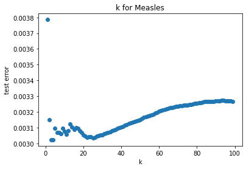

```python
#Plotting k with validation error
import matplotlib.pyplot as plt
plt.scatter(x=k_1, y=error_results)
plt.xlabel('k')
plt.ylabel('test error')
plt.title('k for Measles')
ymin = min(error_results)
```

From the graph above, we see that the optimal k to use is about 25. This is most likely because we reduced our training/test size in half.

We again don't want to pick a k too close to 0, because this error is too good to be true since we would be picking data points too similar to the one we are predicting for.

Next, we take this k and make our predictions.

```python
# Use k=25 to predict
# convert categorical variables to dummy variables
vec = DictVectorizer(sparse=False)
vec.fit(X_train_dict)
X_train = vec.transform(X_train_dict)
X_val = vec.transform(X_val_dict)

# standardize the data
scaler = StandardScaler()
scaler.fit(X_train)
X_train_sc = scaler.transform(X_train)
X_val_sc = scaler.transform(X_val)

# Fit a 25-nearest neighbors model.
model = KNeighborsRegressor(n_neighbors=25)
model.fit(X_train_sc, y_train)

# Make predictions on the validation set.
y_val_pred = model.predict(X_val_sc)
rmse = np.sqrt(((y_val - y_val_pred) ** 2).mean())

#print(y_val_pred)
print('val error: ', ymin)
```

```
val error:  0.003022676298335747
```

If we want to know the chances of catching measles in 1955 in Alabama (about halfway through the predicted dataset, we need to find the index of this datapoint in the dataframe we predicted on and map it to its index in our resulting prediction dataframe.

```python
val[val['Year'] == 1963]
#Find that 1955 ALabama is at index 1227

#1227 - 835 = 392 gives us the index in the predicted array
y_val_pred[392]
```

```
0.001797885794424771
```

```python
#Calculate percent error
#Percentage Error = ((Estimated Number - Actual Number)/ Actual number) x 100
((.001797885794424771 - .000347)/ .000347) * 100
```

```
418.1227073270234
```

Additionally as a note to keep in mind, these incidence numbers are so small that the percent difference between them seems extremely high - so the difference between the percents is important.

### Predictor 3 - What Features Impact our Model?

Now, to examine what happens when remove a feature to predict on, we will remove the income feature. We predict based on our correlations between disease incidence and income that the error will go up.

Since our predictor 2 improved the percent error, we will build off of that model and examine the measles incidence from 1929 to 1963 right before the vaccine came out.

First, we split the data in half. Then, we define our features to train on as the year, state, and population density.

We can use a for loop to test out different k values to use for our k-nearest neighbors model and get a validation error.

```python
#JUST MEASLES PREDICTOR - no income
from pandas.core.dtypes.cast import maybe_unbox_datetimelike_tz_deprecation
from sklearn.feature_extraction import DictVectorizer
from sklearn.preprocessing import StandardScaler

# Fit model to data
from sklearn.neighbors import KNeighborsRegressor

# split data in half up to vaccine release in 1963
# 1669/2 = 834.5
train = measles_together.iloc[0:835]
val = measles_together.iloc[835:1669]

# defining features WITHOUT INCOME
features = ["Year",
            "Name",
            "Pop Density"]

X_train_dict = train[features].to_dict(orient="records")
X_val_dict = val[features].to_dict(orient="records")

y_train = train["Measles Incidence"]
y_val = val["Measles Incidence"]

#For loop to determine optimal k to use
k_1 = [i for i in range(1,100)]
error_results = []
for i in k_1:
  def get_val_error(X_train_dict, y_train, X_val_dict, y_val, i):
    # convert categorical variables to dummy variables
    vec = DictVectorizer(sparse=False)
    vec.fit(X_train_dict)
    X_train = vec.transform(X_train_dict)
    X_val = vec.transform(X_val_dict)

    # standardize the data
    scaler = StandardScaler()
    scaler.fit(X_train)
    X_train_sc = scaler.transform(X_train)
    X_val_sc = scaler.transform(X_val)

    # Fit a 10-nearest neighbors model.
    model = KNeighborsRegressor(n_neighbors=i)
    model.fit(X_train_sc, y_train)

    # Make predictions on the validation set.
    y_val_pred = model.predict(X_val_sc)
    rmse = np.sqrt(((y_val - y_val_pred) ** 2).mean())

    return rmse

  val1 = get_val_error(X_train_dict, y_train, X_val_dict, y_val, i)
  val2 = get_val_error(X_val_dict, y_val, X_train_dict, y_train, i) #reverse
  cross_val = (val1 + val2)/2
  error_results.append(cross_val)
```

We plot these k values and the corresponding errors they give to determine the best k to use.

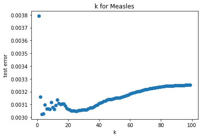

```python
#Plotting k with validation error
import matplotlib.pyplot as plt
plt.scatter(x=k_1, y=error_results)
plt.xlabel('k')
plt.ylabel('test error')
plt.title('k for Measles')
ymin = min(error_results)
```

From the graph above, we see that the optimal k to use is about 25 again, similar to our Model 2.

We again don't want to pick a k too close to 0, because this error is too good to be true since we would be picking data points too similar to the one we are predicting for.

Next, we take this k and make our predictions.

```python
# Use k=25 to predict
# convert categorical variables to dummy variables
vec = DictVectorizer(sparse=False)
vec.fit(X_train_dict)
X_train = vec.transform(X_train_dict)
X_val = vec.transform(X_val_dict)

# standardize the data
scaler = StandardScaler()
scaler.fit(X_train)
X_train_sc = scaler.transform(X_train)
X_val_sc = scaler.transform(X_val)

# Fit a 25-nearest neighbors model.
model = KNeighborsRegressor(n_neighbors=25)
model.fit(X_train_sc, y_train)

# Make predictions on the validation set.
y_val_pred = model.predict(X_val_sc)
rmse = np.sqrt(((y_val - y_val_pred) ** 2).mean())

#print(y_val_pred)
print('val error: ', ymin)
```

```
val error:  0.003024193805600776
```

If we want to know the chances of catching measles in 1955 in Alabama (about halfway through the predicted dataset, we need to find the index of this datapoint in the dataframe we predicted on and map it to its index in our resulting prediction dataframe.

```python
val[val['Year'] == 1955]
#Find that 1955 ALabama is at index 1227

#1227 - 835 = 392 gives us the index in the predicted array
y_val_pred[392]
```

```
0.002084132350947432
```

```python
#Calculate percent error
#Percentage Error = ((Estimated Number - Actual Number)/ Actual number) x 100
((0.002084132350947432 - .000347)/ .000347) * 100
```

```
500.6145103594905
```

The percentage error here is 500%, which is still pretty large, and actually increased from Model 2 by 82%. This increase is as we expected and shows that the correlation we observed earlier between incidence and state income does in fact affect our model.

### Predictor 4 - Removing Population Density

Now, we will examine what happens when remove the population density feature to predict on. We predict based on our correlations between disease incidence and population density that the error will go down. Since our predictor 2 improved the percent error, we will build off of that model.

Again, we examine the measles incidence from 1929 to 1963 right before the vaccine came out.

We can use a for loop to test out different k values to use for our k-nearest neighbors model and get a validation error.

```python
#JUST MEASLES PREDICTOR - no income
from pandas.core.dtypes.cast import maybe_unbox_datetimelike_tz_deprecation
from sklearn.feature_extraction import DictVectorizer
from sklearn.preprocessing import StandardScaler

# Fit model to data
from sklearn.neighbors import KNeighborsRegressor

# split data in half up to vaccine release in 1963
# 1669/2 = 834.5
train = measles_together.iloc[0:835]
val = measles_together.iloc[835:1669]

# defining features WITHOUT POPULATION DENSITY
features = ["Year",
            "Name",
            "Income"]

X_train_dict = train[features].to_dict(orient="records")
X_val_dict = val[features].to_dict(orient="records")

y_train = train["Measles Incidence"]
y_val = val["Measles Incidence"]

#For loop to determine optimal k to use
k_1 = [i for i in range(1,100)]
error_results = []
for i in k_1:
  def get_val_error(X_train_dict, y_train, X_val_dict, y_val, i):
    # convert categorical variables to dummy variables
    vec = DictVectorizer(sparse=False)
    vec.fit(X_train_dict)
    X_train = vec.transform(X_train_dict)
    X_val = vec.transform(X_val_dict)

    # standardize the data
    scaler = StandardScaler()
    scaler.fit(X_train)
    X_train_sc = scaler.transform(X_train)
    X_val_sc = scaler.transform(X_val)

    # Fit a 10-nearest neighbors model.
    model = KNeighborsRegressor(n_neighbors=i)
    model.fit(X_train_sc, y_train)

    # Make predictions on the validation set.
    y_val_pred = model.predict(X_val_sc)
    rmse = np.sqrt(((y_val - y_val_pred) ** 2).mean())

    return rmse

  val1 = get_val_error(X_train_dict, y_train, X_val_dict, y_val, i)
  val2 = get_val_error(X_val_dict, y_val, X_train_dict, y_train, i) #reverse
  cross_val = (val1 + val2)/2
  error_results.append(cross_val)
```

We plot these k values and the corresponding errors they give to determine the best k to use.

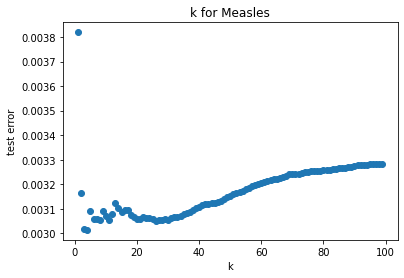

```python
#Plotting k with validation error
import matplotlib.pyplot as plt
plt.scatter(x=k_1, y=error_results)
plt.xlabel('k')
plt.ylabel('test error')
plt.title('k for Measles')
ymin = min(error_results)
```

From the graph above, we see that the optimal k to use is about 25 again, similar to our Model 2.

We again don't want to pick a k too close to 0, because this error is too good to be true since we would be picking data points too similar to the one we are predicting for.

Next, we take this k and make our predictions.

```python
# Use k=25 to predict
# convert categorical variables to dummy variables
vec = DictVectorizer(sparse=False)
vec.fit(X_train_dict)
X_train = vec.transform(X_train_dict)
X_val = vec.transform(X_val_dict)

# standardize the data
scaler = StandardScaler()
scaler.fit(X_train)
X_train_sc = scaler.transform(X_train)
X_val_sc = scaler.transform(X_val)

# Fit a 25-nearest neighbors model.
model = KNeighborsRegressor(n_neighbors=25)
model.fit(X_train_sc, y_train)

# Make predictions on the validation set.
y_val_pred = model.predict(X_val_sc)
rmse = np.sqrt(((y_val - y_val_pred) ** 2).mean())

#print(y_val_pred)
print('val error: ', ymin)
```

```
val error:  0.003014331688575157
```

If we want to know the chances of catching measles in 1955 in Alabama (about halfway through the predicted dataset, we need to find the index of this datapoint in the dataframe we predicted on and map it to its index in our resulting prediction dataframe.

```python
val[val['Year'] == 1955]
#Find that 1955 ALabama is at index 1227

#1227 - 835 = 392 gives us the index in the predicted array
y_val_pred[392]
```

```
0.002045478209686451
```

```python
#Calculate percent error
#Percentage Error = ((Estimated Number - Actual Number)/ Actual number) x 100
((0.002045478209686451 - .000347)/ .000347) * 100
```

```
489.4749883822625
```

The percentage error here is 489%, which increased from Model 2 by 71%. This increase is not what we expected; however, it has slightly less of an increase as compared to Model 3, meaning that population density may have had less of an effect than income.

```python
%%shell

jupyter nbconvert --to html "/content/drive/MyDrive/cmps3160/finalProject/Final_Project_Disease_Prevalence.ipynb"
```

[output not shown]

[output cut: 107 more lines]

[output not shown]

[output not shown]

## Conclusions and Summary

Throughout this project we completed a lot of analysis specifically on disease incidence and trends between states within the population. We utilized several visualization techniques to demonstrate the variances both across the years as well as between states both seperate and in comparison to national trends. In an effort to understand these numbers more in depth, we included datasets focused on state population density and state average income level. We measured the correlation between each of these variables and disease incidence for every state over the years, and discovered that both population density and state average income feature a moderate negative correlation. From here we built dour different predictive models in an attempt to really demonstrate what variables could be related, and we discovered that the strongest thing to improve our model's predictions was to pick a smaller time. All of this indicates that while population density and state average income are potentially pieces of the complicated puzzle of disease spread, they are certainly not the whole picture, and without a better understanding of the individual people that make up those case numbers, our knowledge and what assumptions we can make are limited.